# Legalization of Cannabis and Its Healthcare and Workplace Consequences

### 2.3.6 All Meds: Payment

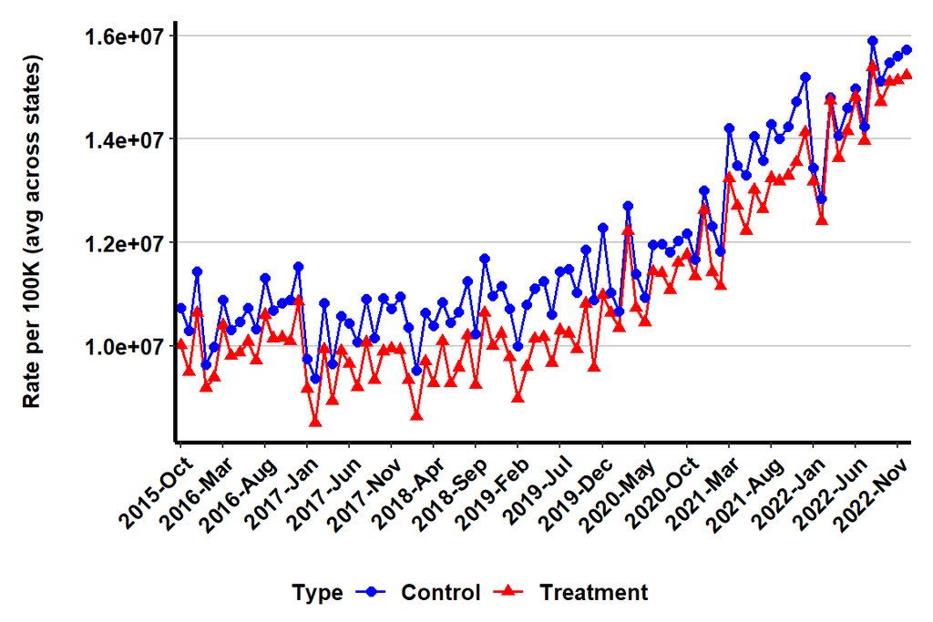

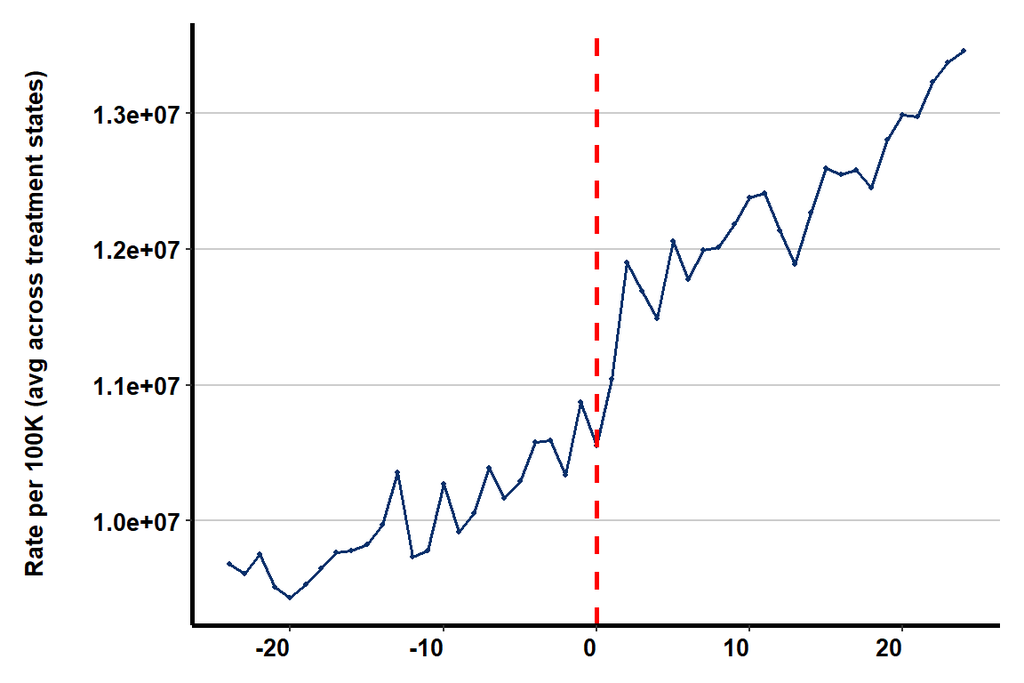

### 2.3.7 MHD Meds: Number

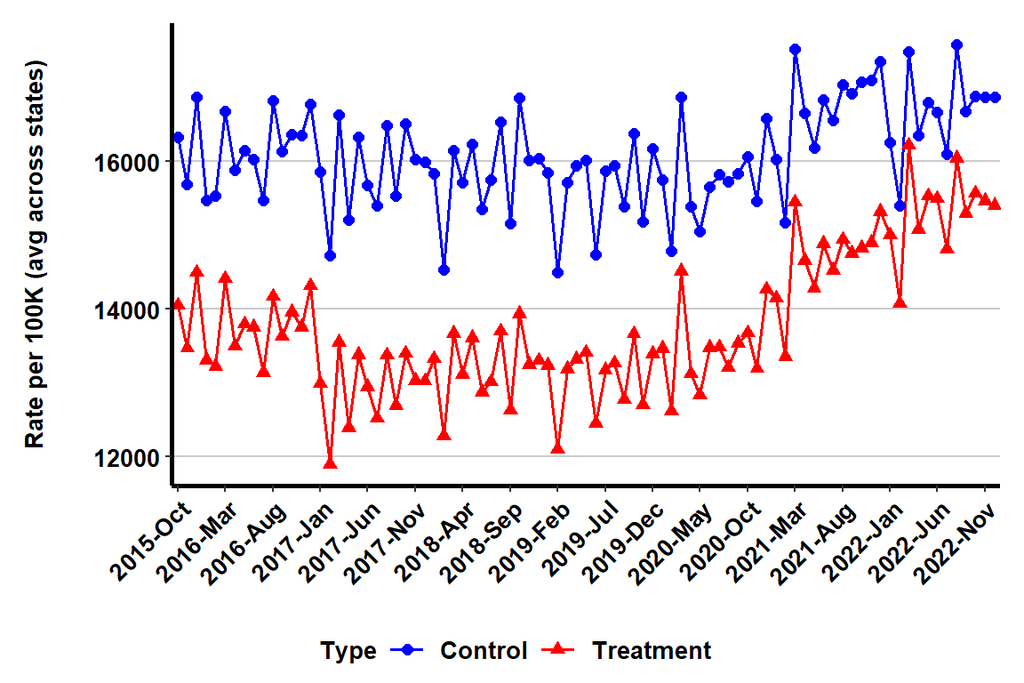

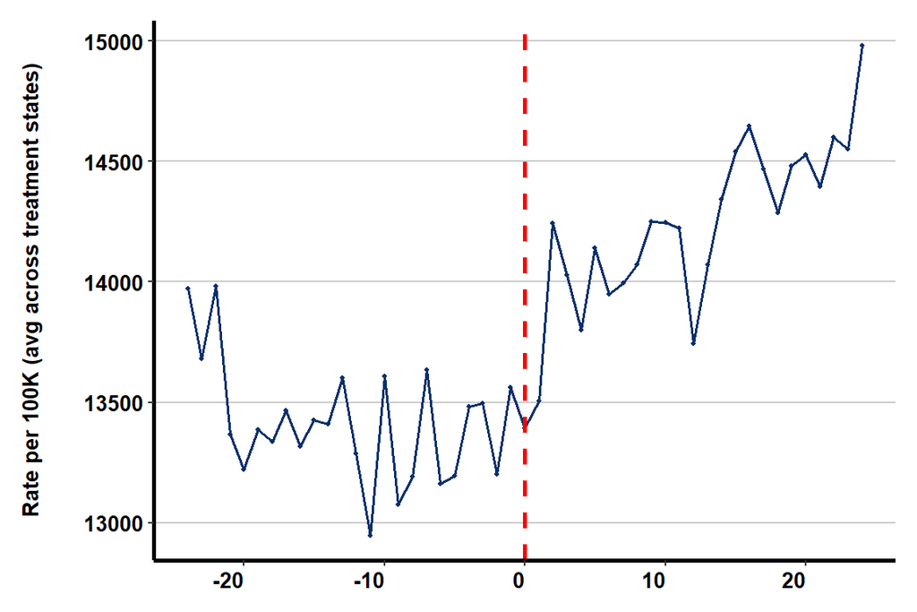

### 2.3.8 MHD Meds: Payment

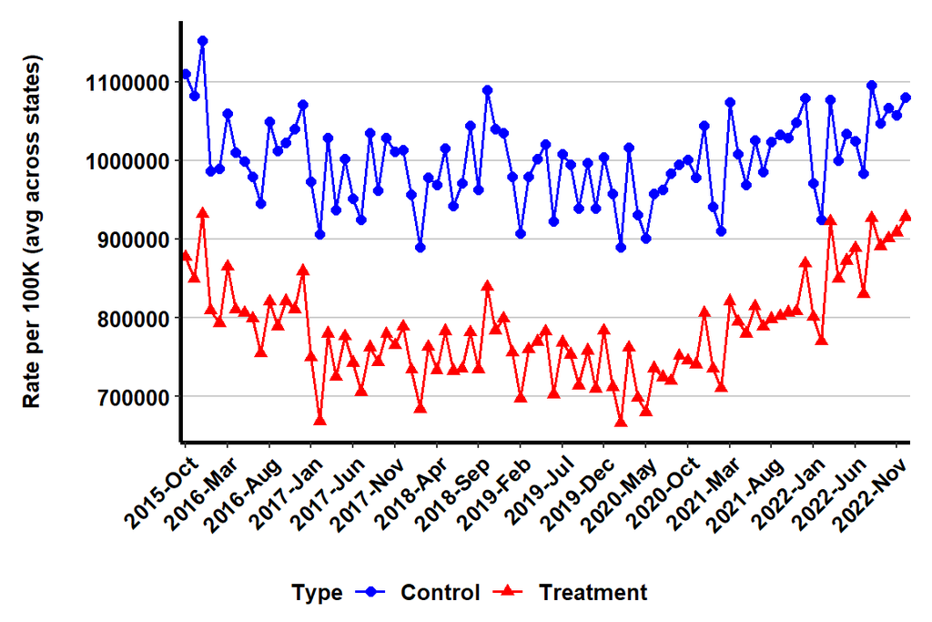

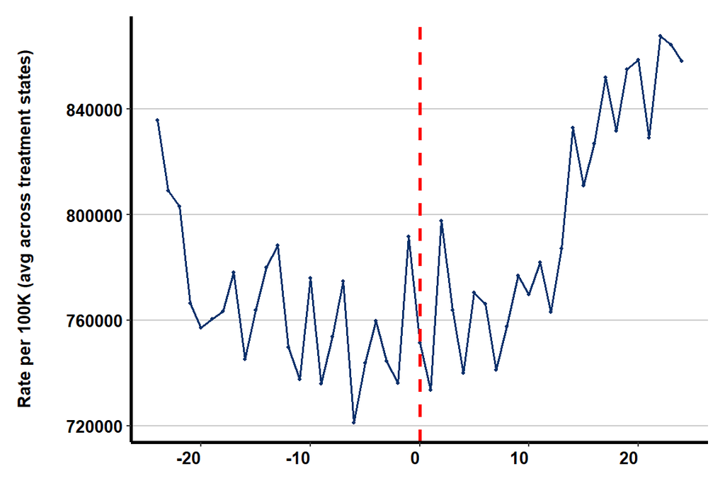

# 3 Empirical Analyses

To quantify the effect of cannabis legalization, we use the following staggered difference-in-differences (DiD) specification.

$$Y_{it} = \beta Post_{it} + \alpha X_{it} + \delta_i + \eta_t + \epsilon_{it},$$
where $Y_{it}$ is the outcome of interest in state $i$ and year $t$; $Post_{it}$ is a binary indicator for the enactment of legalization laws, which equals 1 for all the years following the enactment in treatment states, and 0 otherwise; $\delta_i$ is a set of state fixed effects that account for the time-invariant state characteristics; $\eta_t$ is a set of month fixed effects that account for the national trends that might have impacted the outcome; $X_{it}$ is a set of time-varying control variables.

An important assumption underlying the DiD specification is that the differences between the outcome in states that legalized the recreational use of cannabis (versus those states that did not legalize) is not due to the pre-existing trends before the legalization, which is know as the **parallel trends assumption.** To validate this assumption, we estimate the following **event-study model** (a.k.a. **event time analysis**) to examine the dynamics in the impact of legalization on the outcome of interest in the treatment states.

$$Y_{it} = \sum_{\tau} \beta_{\tau} time_{i\tau} + \alpha X_{it} + \delta_i + \eta_t + \epsilon_{it},$$
where $time_{i\tau}$ is a set of dummies for the number of months relative to the legalization, and $\beta_{\tau}$ represents the difference between treatment and control states in period $\tau$.

The following tables and figures present the results for different outcome variables. In each table, we estimate the models using OLS method with (columns 3-4) and without (columns 1-2) log transformation of the outcome. Moreover, in columns 1 and 3, we do not include time-varying controls. In all models, the robust standard errors are clustered at the state level.

For each outcome, we present the results of our DiD analysis under two scenarios: no lead (baseline) and 6-month lead (where an outcome of interest is measured 6 months from the time of intervention). This is to account for the fact that there might be a delay between legalization and its impact on the outcome variables.

Table 3.1: Description of Outcomes and Variables

| Variables | Description | Source | Measurement |
| --- | --- | --- | --- |
| CUD | Cannabis use disorder | Our data | Per 100K enrollees |
| OUD | Opioid use disorder | Our data | Per 100K enrollees |
| Rec_disp | Dispensary of cannabis (dispensary date) for recreational use | External | — |
| Rec_eff | Legalization of cannabis (effective date) for recreational use | External | — |
| Med_disp | Dispensary of cannabis (dispensary date) for medical use | External | — |
| Med_eff | Legalization of cannabis (effective date) for medical use | External | — |
| Spillover | Number of neighboring states that have started dispensary of cannabis (medical or recreational use) | External | — |
| Population | State’s population | External | — |
| Age | Rate of people within 18-54 age range | Our data | Per 100K enrollees |
| Gender | Rate of female patients | Our data | — |
| Race | Rate of people with non-White races/ethnicities | External | — |
| MDI | Multi-dimensional deprivation index (proxy for socio-economic status) | External | — |
| Employment | Rate of people with full/part-time employment | Our data | Per 100K enrollees |
| Industry | Rate of people from manufacturing or transportation industries | Our data | Per 100K enrollees |
| Insurance_plan | Rate of people with HMO or PPO insurance plans | Our data | Per 100K enrollees |
| Days_abs | Rate of days that people miss work (work absenteeism) | Our data | Per 100K enrollees |
| AUD | Rate of people with alcohol use disorders | Our data | Per 100K enrollees |
| MHD | Rate of people with mental health disorders (excluding AUD/CUD/OUD) | Our data | Per 100K enrollees |
| Healthcare_exp | Rate of healthcare expenditures | External | Per Capita |
| Hospitals | Rate of hospitals | External | Per 100K Capita |
| Officers | Rate of law enforecement officers | External | Per 1K Capita |
| Crime | Rate of cime (violent + non-violent) | External | Per 100K Capita |
| Drug_seize | Rate of narcotics/anagelstics/cannabis drugs seized by the DEI (proxy for illicit use/illegal market) | External | Per 100K Capita |
| Mandate_covid | Indicator: whether there was a COVID-related mandate | External | — |

## 3.1 Outcomes related to CUD

### 3.1.1 Prevalence

**Outcome: baseline**

|  | No Transformation |  | Log Transformed |  |
| --- | --- | --- | --- | --- |
|  | (1) | (2) | (3) | (4) |
| Rec_disp | 9.776 | 5.736 | 0.210* | 0.171 |
|  | (7.834) | (4.339) | (0.110) | (0.114) |
| Rec_eff |  | -7.776 |  | -0.046 |
|  |  | (6.823) |  | (0.088) |
| Med_disp |  | 0.342 |  | 0.099 |
|  |  | (4.957) |  | (0.079) |
| Med_eff |  | -1.565 |  | 0.060 |
|  |  | (4.994) |  | (0.093) |
| Spillover |  | 0.211 |  | 0.006 |
|  |  | (2.413) |  | (0.039) |
| Population |  | -0.00000 |  | 0.00000 |
|  |  | (0.00001) |  | (0.00000) |
| Age |  | 80.510 |  | 2.639** |
|  |  | (65.393) |  | (0.995) |
| Gender |  | -154.539 |  | -0.855 |
|  |  | (114.706) |  | (3.607) |
| Race |  | 49.501* |  | 0.178 |
|  |  | (28.317) |  | (0.580) |
| MDI |  | 1.451 |  | 0.049 |
|  |  | (1.713) |  | (0.041) |
| Employment |  | -10.484 |  | -1.437* |
|  |  | (23.294) |  | (0.751) |
| Industry |  | 19.305 |  | 0.963 |
|  |  | (29.358) |  | (0.669) |
| Insurance_plan |  | -19.977 |  | -0.266 |
|  |  | (15.428) |  | (0.172) |
| Days_abs |  | -0.00000 |  | -0.000** |
|  |  | (0.00000) |  | (0.000) |
| MHD |  | 0.005*** |  | 0.0001* |
|  |  | (0.001) |  | (0.0001) |
| AUD |  | 0.106*** |  | 0.001** |
|  |  | (0.027) |  | (0.001) |
| Healthcare_exp |  | 0.007 |  | 0.0001 |
|  |  | (0.007) |  | (0.0001) |
| Hospitals |  | -12.425* |  | 0.117 |
|  |  | (7.357) |  | (0.200) |
| Officers |  | -1.982 |  | -0.102 |
|  |  | (6.717) |  | (0.083) |
| Crime |  | -0.002 |  | -0.00003 |
|  |  | (0.002) |  | (0.00003) |
| Drug_seize |  | -0.034 |  | -0.002 |
|  |  | (0.066) |  | (0.001) |
| Mandate_covid |  | 14.030 |  | 0.090 |
|  |  | (8.528) |  | (0.138) |
| Controls | No | Yes | No | Yes |
| FE: State/Year | Yes | Yes | Yes | Yes |
| Observations | 3,741 | 3,741 | 3,741 | 3,741 |
| R<sup>2</sup> | 0.419 | 0.494 | 0.536 | 0.694 |
| Adjusted R<sup>2</sup> | 0.398 | 0.473 | 0.519 | 0.681 |
| *Note:* | p<0.1; p<0.05; p<0.01 |  |  |  |
|  | Robust standard errors are clustered at the state level |  |  |  |

**Outcome: lead (6 months)**

|  | No Transformation |  | Log Transformed |  |
| --- | --- | --- | --- | --- |
|  | (1) | (2) | (3) | (4) |
| Rec_disp | 13.756 | 10.346 | 0.233* | 0.220 |
|  | (9.470) | (8.919) | (0.130) | (0.150) |
| Rec_eff |  | 0.154 |  | 0.056 |
|  |  | (9.152) |  | (0.126) |
| Med_disp |  | 0.611 |  | 0.107 |
|  |  | (4.747) |  | (0.072) |
| Med_eff |  | -11.330* |  | -0.041 |
|  |  | (6.364) |  | (0.088) |
| Spillover |  | 0.440 |  | 0.0004 |
|  |  | (3.020) |  | (0.044) |
| Population |  | -0.00000 |  | 0.00000 |
|  |  | (0.00001) |  | (0.00000) |
| Age |  | 159.992** |  | 5.156*** |
|  |  | (65.620) |  | (1.624) |
| Gender |  | -40.314 |  | 0.875 |
|  |  | (171.410) |  | (3.778) |
| Race |  | 47.464 |  | 0.007 |
|  |  | (63.366) |  | (0.892) |
| MDI |  | 2.410 |  | 0.085* |
|  |  | (2.336) |  | (0.046) |
| Employment |  | 2.201 |  | -2.164** |
|  |  | (22.521) |  | (1.003) |
| Industry |  | -6.602 |  | 0.770 |
|  |  | (32.310) |  | (0.672) |
| Insurance_plan |  | -21.830 |  | -0.085 |
|  |  | (26.516) |  | (0.322) |
| Days_abs |  | -0.00000** |  | -0.00000*** |
|  |  | (0.00000) |  | (0.000) |
| MHD |  | 0.004** |  | 0.0001** |
|  |  | (0.002) |  | (0.0001) |
| AUD |  | 0.019 |  | 0.0003 |
|  |  | (0.037) |  | (0.001) |
| Healthcare_exp |  | 0.006 |  | 0.0001 |
|  |  | (0.007) |  | (0.0001) |
| Hospitals |  | -9.997 |  | 0.124 |
|  |  | (9.992) |  | (0.219) |
| Officers |  | -13.754 |  | -0.168 |
|  |  | (12.140) |  | (0.143) |
| Crime |  | -0.0002 |  | -0.00001 |
|  |  | (0.001) |  | (0.00002) |
| Drug_seize |  | -0.078 |  | -0.001 |
|  |  | (0.070) |  | (0.001) |
| Mandate_covid |  | 4.044 |  | -0.055 |
|  |  | (6.031) |  | (0.101) |
| Controls | No | Yes | No | Yes |
| FE: State/Year | Yes | Yes | Yes | Yes |
| Observations | 3,483 | 3,483 | 3,483 | 3,483 |
| R<sup>2</sup> | 0.408 | 0.438 | 0.524 | 0.619 |
| Adjusted R<sup>2</sup> | 0.387 | 0.414 | 0.507 | 0.602 |
| *Note:* | p<0.1; p<0.05; p<0.01 |  |  |  |
|  | Robust standard errors are clustered at the state level |  |  |  |

Under the baseline scenario, we now present the estimated coefficients from the event-study model.

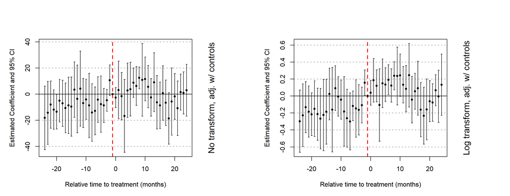

### 3.1.2 IP Admissions

**Outcome: baseline**

|  | No Transformation |  | Log Transformed |  |
| --- | --- | --- | --- | --- |
|  | (1) | (2) | (3) | (4) |
| Rec_disp | -0.118 | -0.058 | 0.063 | 0.067 |
|  | (1.130) | (0.838) | (0.126) | (0.102) |
| Rec_eff |  | -0.616 |  | -0.084 |
|  |  | (0.784) |  | (0.085) |
| Med_disp |  | 0.348 |  | 0.105* |
|  |  | (0.460) |  | (0.059) |
| Med_eff |  | -0.788 |  | 0.028 |
|  |  | (0.722) |  | (0.069) |
| Spillover |  | -0.280 |  | -0.025 |
|  |  | (0.235) |  | (0.025) |
| Population |  | 0.00000 |  | 0.00000* |
|  |  | (0.00000) |  | (0.00000) |
| Age |  | 24.648** |  | 2.101*** |
|  |  | (11.534) |  | (0.587) |
| Gender |  | -23.055 |  | -1.416 |
|  |  | (18.511) |  | (1.758) |
| Race |  | 11.540** |  | 0.958** |
|  |  | (4.475) |  | (0.400) |
| MDI |  | 0.449 |  | 0.033 |
|  |  | (0.282) |  | (0.025) |
| Employment |  | -5.116** |  | -1.281** |
|  |  | (2.448) |  | (0.487) |
| Industry |  | -0.678 |  | 0.507 |
|  |  | (4.569) |  | (0.432) |
| Insurance_plan |  | -2.694 |  | -0.451* |
|  |  | (2.205) |  | (0.237) |
| Days_abs |  | -0.000* |  | -0.000** |
|  |  | (0.000) |  | (0.000) |
| MHD |  | 0.0003 |  | 0.0001* |
|  |  | (0.0002) |  | (0.00004) |
| AUD |  | -0.0002 |  | 0.0004 |
|  |  | (0.004) |  | (0.0005) |
| Healthcare_exp |  | 0.002** |  | 0.0002* |
|  |  | (0.001) |  | (0.0001) |
| Hospitals |  | -2.054 |  | -0.195 |
|  |  | (1.280) |  | (0.188) |
| Officers |  | -0.235 |  | -0.004 |
|  |  | (0.806) |  | (0.098) |
| Crime |  | 0.0003 |  | 0.00003 |
|  |  | (0.0003) |  | (0.00002) |
| Drug_seize |  | 0.004 |  | 0.0002 |
|  |  | (0.007) |  | (0.001) |
| Mandate_covid |  | -0.343 |  | 0.002 |
|  |  | (0.720) |  | (0.091) |
| Controls | No | Yes | No | Yes |
| FE: State/Year | Yes | Yes | Yes | Yes |
| Observations | 3,741 | 3,741 | 3,741 | 3,741 |
| R<sup>2</sup> | 0.061 | 0.071 | 0.328 | 0.382 |
| Adjusted R<sup>2</sup> | 0.027 | 0.032 | 0.304 | 0.356 |
| *Note:* | p<0.1; p<0.05; p<0.01 |  |  |  |
|  | Robust standard errors are clustered at the state level |  |  |  |

**Outcome: lead (6 months)**

|  | No Transformation |  | Log Transformed |  |
| --- | --- | --- | --- | --- |
|  | (1) | (2) | (3) | (4) |
| Rec_disp | 0.330 | 0.633 | 0.100 | 0.126 |
|  | (1.139) | (1.035) | (0.138) | (0.109) |
| Rec_eff |  | -1.011 |  | -0.111 |
|  |  | (0.751) |  | (0.079) |
| Med_disp |  | 0.868** |  | 0.102* |
|  |  | (0.402) |  | (0.059) |
| Med_eff |  | -1.238* |  | -0.024 |
|  |  | (0.654) |  | (0.074) |
| Spillover |  | -0.226 |  | -0.016 |
|  |  | (0.263) |  | (0.026) |
| Population |  | 0.00000 |  | 0.00000 |
|  |  | (0.00000) |  | (0.00000) |
| Age |  | 17.539*** |  | 2.730*** |
|  |  | (5.885) |  | (0.982) |
| Gender |  | -21.118 |  | 0.480 |
|  |  | (25.801) |  | (1.821) |
| Race |  | 16.368 |  | 1.070 |
|  |  | (9.937) |  | (0.931) |
| MDI |  | 0.325 |  | 0.038 |
|  |  | (0.243) |  | (0.027) |
| Employment |  | -4.032 |  | -1.500** |
|  |  | (3.882) |  | (0.586) |
| Industry |  | -3.616 |  | 0.259 |
|  |  | (4.900) |  | (0.368) |
| Insurance_plan |  | -5.613 |  | -0.365 |
|  |  | (3.747) |  | (0.248) |
| Days_abs |  | -0.00000 |  | -0.000*** |
|  |  | (0.00000) |  | (0.000) |
| MHD |  | 0.0001 |  | 0.00003 |
|  |  | (0.0002) |  | (0.00003) |
| AUD |  | -0.007 |  | 0.0002 |
|  |  | (0.006) |  | (0.0002) |
| Healthcare_exp |  | 0.002** |  | 0.0002* |
|  |  | (0.001) |  | (0.0001) |
| Hospitals |  | -0.830 |  | -0.004 |
|  |  | (1.799) |  | (0.230) |
| Officers |  | -1.051 |  | 0.072 |
|  |  | (1.637) |  | (0.119) |
| Crime |  | 0.0003** |  | 0.00003 |
|  |  | (0.0002) |  | (0.00002) |
| Drug_seize |  | -0.008 |  | -0.0001 |
|  |  | (0.010) |  | (0.001) |
| Mandate_covid |  | 0.450 |  | 0.039 |
|  |  | (0.799) |  | (0.081) |
| Controls | No | Yes | No | Yes |
| FE: State/Year | Yes | Yes | Yes | Yes |
| Observations | 3,483 | 3,483 | 3,483 | 3,483 |
| R<sup>2</sup> | 0.059 | 0.067 | 0.322 | 0.359 |
| Adjusted R<sup>2</sup> | 0.024 | 0.027 | 0.297 | 0.331 |
| *Note:* | p<0.1; p<0.05; p<0.01 |  |  |  |
|  | Robust standard errors are clustered at the state level |  |  |  |

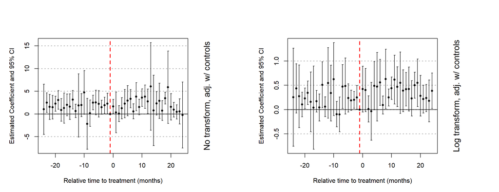

### 3.1.3 Length of Stay (LOS)

**Outcome: baseline**

|  | No Transformation |  | Log Transformed |  |
| --- | --- | --- | --- | --- |
|  | (1) | (2) | (3) | (4) |
| Rec_disp | 9.035 | 8.778 | 0.223 | 0.236 |
|  | (6.787) | (6.096) | (0.167) | (0.181) |
| Rec_eff |  | -1.151 |  | -0.128 |
|  |  | (5.204) |  | (0.129) |
| Med_disp |  | 4.128 |  | 0.123 |
|  |  | (4.472) |  | (0.131) |
| Med_eff |  | -0.362 |  | 0.070 |
|  |  | (2.777) |  | (0.102) |
| Spillover |  | 1.689 |  | -0.006 |
|  |  | (2.001) |  | (0.047) |
| Population |  | 0.00000 |  | 0.00000* |
|  |  | (0.00000) |  | (0.00000) |
| Age |  | 45.776 |  | 2.389** |
|  |  | (39.522) |  | (1.127) |
| Gender |  | 24.228 |  | -0.821 |
|  |  | (97.706) |  | (3.306) |
| Race |  | 13.092 |  | 0.924 |
|  |  | (25.791) |  | (0.722) |
| MDI |  | 0.082 |  | 0.027 |
|  |  | (1.256) |  | (0.038) |
| Employment |  | -48.207*** |  | -2.491** |
|  |  | (16.410) |  | (1.005) |
| Industry |  | 31.970* |  | 1.244 |
|  |  | (18.364) |  | (0.753) |
| Insurance_plan |  | -11.095 |  | -0.276 |
|  |  | (17.724) |  | (0.379) |
| Days_abs |  | -0.00000* |  | -0.000** |
|  |  | (0.00000) |  | (0.000) |
| MHD |  | 0.001 |  | 0.0001* |
|  |  | (0.002) |  | (0.0001) |
| AUD |  | 0.036 |  | 0.001 |
|  |  | (0.027) |  | (0.001) |
| Healthcare_exp |  | 0.008* |  | 0.0003* |
|  |  | (0.004) |  | (0.0002) |
| Hospitals |  | -17.267** |  | -0.466 |
|  |  | (8.320) |  | (0.355) |
| Officers |  | -2.771 |  | 0.026 |
|  |  | (5.757) |  | (0.157) |
| Crime |  | 0.002* |  | 0.00002 |
|  |  | (0.001) |  | (0.00003) |
| Drug_seize |  | -0.003 |  | -0.001 |
|  |  | (0.062) |  | (0.002) |
| Mandate_covid |  | 2.700 |  | 0.0002 |
|  |  | (4.573) |  | (0.122) |
| Controls | No | Yes | No | Yes |
| FE: State/Year | Yes | Yes | Yes | Yes |
| Observations | 3,741 | 3,741 | 3,741 | 3,741 |
| R<sup>2</sup> | 0.125 | 0.144 | 0.383 | 0.438 |
| Adjusted R<sup>2</sup> | 0.094 | 0.108 | 0.361 | 0.415 |
| *Note:* | p<0.1; p<0.05; p<0.01 |  |  |  |
|  | Robust standard errors are clustered at the state level |  |  |  |

**Outcome: lead (6 months)**

|  | No Transformation |  | Log Transformed |  |
| --- | --- | --- | --- | --- |
|  | (1) | (2) | (3) | (4) |
| Rec_disp | 7.714 | 7.975 | 0.275 | 0.311 |
|  | (7.312) | (6.951) | (0.190) | (0.193) |
| Rec_eff |  | -4.247 |  | -0.149 |
|  |  | (4.857) |  | (0.123) |
| Med_disp |  | 6.325 |  | 0.158 |
|  |  | (4.981) |  | (0.132) |
| Med_eff |  | -7.884 |  | -0.067 |
|  |  | (5.777) |  | (0.147) |
| Spillover |  | 1.816 |  | 0.011 |
|  |  | (2.088) |  | (0.045) |
| Population |  | 0.00000 |  | 0.00000 |
|  |  | (0.00001) |  | (0.00000) |
| Age |  | 56.754 |  | 4.174** |
|  |  | (57.081) |  | (1.859) |
| Gender |  | 127.508 |  | 3.037 |
|  |  | (111.093) |  | (3.328) |
| Race |  | 31.321 |  | 0.837 |
|  |  | (49.231) |  | (1.457) |
| MDI |  | -0.003 |  | 0.042 |
|  |  | (1.375) |  | (0.042) |
| Employment |  | -72.163*** |  | -3.266*** |
|  |  | (21.253) |  | (1.206) |
| Industry |  | 32.320* |  | 1.050 |
|  |  | (18.962) |  | (0.659) |
| Insurance_plan |  | -9.468 |  | -0.121 |
|  |  | (16.823) |  | (0.407) |
| Days_abs |  | -0.00000** |  | -0.00000*** |
|  |  | (0.00000) |  | (0.000) |
| MHD |  | -0.0004 |  | 0.0001 |
|  |  | (0.002) |  | (0.0001) |
| AUD |  | 0.040* |  | 0.0003 |
|  |  | (0.020) |  | (0.0003) |
| Healthcare_exp |  | 0.009* |  | 0.0002 |
|  |  | (0.005) |  | (0.0002) |
| Hospitals |  | 2.325 |  | -0.004 |
|  |  | (14.294) |  | (0.451) |
| Officers |  | 5.628 |  | 0.230 |
|  |  | (8.846) |  | (0.145) |
| Crime |  | 0.001 |  | 0.00003 |
|  |  | (0.002) |  | (0.00003) |
| Drug_seize |  | -0.010 |  | -0.0001 |
|  |  | (0.070) |  | (0.002) |
| Mandate_covid |  | 1.707 |  | 0.037 |
|  |  | (4.839) |  | (0.129) |
| Controls | No | Yes | No | Yes |
| FE: State/Year | Yes | Yes | Yes | Yes |
| Observations | 3,483 | 3,483 | 3,483 | 3,483 |
| R<sup>2</sup> | 0.118 | 0.137 | 0.381 | 0.420 |
| Adjusted R<sup>2</sup> | 0.085 | 0.100 | 0.358 | 0.395 |
| *Note:* | p<0.1; p<0.05; p<0.01 |  |  |  |
|  | Robust standard errors are clustered at the state level |  |  |  |

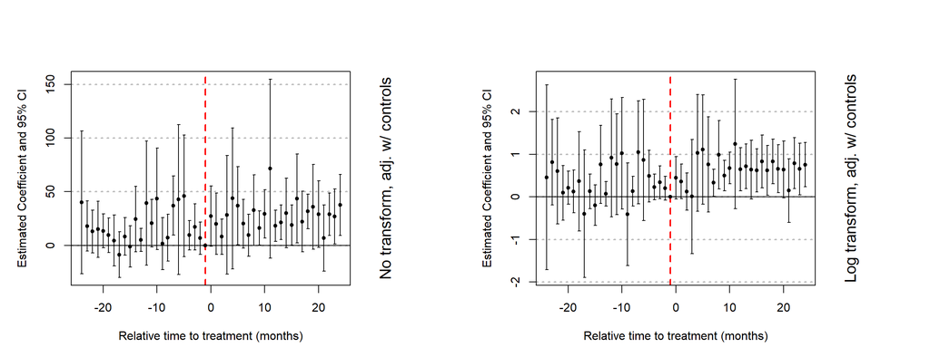

### 3.1.4 ER Visits

**Outcome: baseline**

|  | No Transformation |  | Log Transformed |  |
| --- | --- | --- | --- | --- |
|  | (1) | (2) | (3) | (4) |
| Rec_disp | 4.881 | 6.150** | 0.060 | 0.103 |
|  | (4.067) | (2.394) | (0.182) | (0.129) |
| Rec_eff |  | -8.142** |  | -0.302** |
|  |  | (3.552) |  | (0.135) |
| Med_disp |  | 1.086 |  | 0.057 |
|  |  | (1.953) |  | (0.076) |
| Med_eff |  | 0.631 |  | 0.113 |
|  |  | (3.345) |  | (0.123) |
| Spillover |  | 0.777 |  | 0.011 |
|  |  | (1.216) |  | (0.039) |
| Population |  | -0.00000 |  | 0.00000 |
|  |  | (0.00000) |  | (0.00000) |
| Age |  | 45.106 |  | 1.070 |
|  |  | (38.668) |  | (1.061) |
| Gender |  | -103.252 |  | -1.487 |
|  |  | (62.686) |  | (3.068) |
| Race |  | 24.077 |  | 0.875 |
|  |  | (23.873) |  | (0.700) |
| MDI |  | 0.484 |  | 0.040 |
|  |  | (1.006) |  | (0.057) |
| Employment |  | 3.917 |  | -0.943 |
|  |  | (15.295) |  | (0.609) |
| Industry |  | 8.103 |  | 1.330** |
|  |  | (13.087) |  | (0.494) |
| Insurance_plan |  | 9.004 |  | -0.045 |
|  |  | (5.526) |  | (0.276) |
| Days_abs |  | -0.00000 |  | -0.000** |
|  |  | (0.00000) |  | (0.000) |
| MHD |  | 0.001 |  | 0.0001** |
|  |  | (0.001) |  | (0.00004) |
| AUD |  | 0.058*** |  | 0.002*** |
|  |  | (0.009) |  | (0.001) |
| Healthcare_exp |  | 0.001 |  | 0.0001 |
|  |  | (0.003) |  | (0.0001) |
| Hospitals |  | -10.131 |  | -0.161 |
|  |  | (7.913) |  | (0.318) |
| Officers |  | -1.143 |  | -0.019 |
|  |  | (3.040) |  | (0.193) |
| Crime |  | -0.001 |  | -0.0001 |
|  |  | (0.001) |  | (0.00005) |
| Drug_seize |  | -0.008 |  | -0.001 |
|  |  | (0.031) |  | (0.001) |
| Mandate_covid |  | 11.740*** |  | 0.505*** |
|  |  | (3.255) |  | (0.148) |
| Controls | No | Yes | No | Yes |
| FE: State/Year | Yes | Yes | Yes | Yes |
| Observations | 3,741 | 3,741 | 3,741 | 3,741 |
| R<sup>2</sup> | 0.274 | 0.326 | 0.503 | 0.581 |
| Adjusted R<sup>2</sup> | 0.248 | 0.298 | 0.485 | 0.563 |
| *Note:* | p<0.1; p<0.05; p<0.01 |  |  |  |
|  | Robust standard errors are clustered at the state level |  |  |  |

**Outcome: lead (6 months)**

|  | No Transformation |  | Log Transformed |  |
| --- | --- | --- | --- | --- |
|  | (1) | (2) | (3) | (4) |
| Rec_disp | 6.058 | 7.060 | 0.097 | 0.107 |
|  | (4.677) | (5.041) | (0.225) | (0.232) |
| Rec_eff |  | -3.134 |  | -0.131 |
|  |  | (4.572) |  | (0.191) |
| Med_disp |  | 0.649 |  | -0.008 |
|  |  | (2.175) |  | (0.105) |
| Med_eff |  | -4.809** |  | -0.082 |
|  |  | (2.318) |  | (0.108) |
| Spillover |  | 0.461 |  | -0.007 |
|  |  | (1.663) |  | (0.051) |
| Population |  | -0.00000 |  | 0.00000 |
|  |  | (0.00000) |  | (0.00000) |
| Age |  | 70.789** |  | 3.792*** |
|  |  | (27.129) |  | (1.291) |
| Gender |  | -73.505 |  | -0.241 |
|  |  | (86.118) |  | (3.641) |
| Race |  | 19.686 |  | 0.238 |
|  |  | (36.365) |  | (0.996) |
| MDI |  | 0.957 |  | 0.046 |
|  |  | (0.765) |  | (0.045) |
| Employment |  | 2.704 |  | -1.444** |
|  |  | (12.300) |  | (0.586) |
| Industry |  | 2.697 |  | 1.012 |
|  |  | (15.511) |  | (0.612) |
| Insurance_plan |  | -7.651 |  | -0.165 |
|  |  | (12.166) |  | (0.366) |
| Days_abs |  | -0.00000* |  | -0.000*** |
|  |  | (0.00000) |  | (0.000) |
| MHD |  | 0.001 |  | 0.0001* |
|  |  | (0.001) |  | (0.00004) |
| AUD |  | -0.006 |  | 0.0003 |
|  |  | (0.017) |  | (0.001) |
| Healthcare_exp |  | 0.0003 |  | 0.0001 |
|  |  | (0.003) |  | (0.0001) |
| Hospitals |  | -3.170 |  | 0.233 |
|  |  | (9.488) |  | (0.497) |
| Officers |  | -9.219 |  | -0.190 |
|  |  | (7.571) |  | (0.251) |
| Crime |  | 0.0002 |  | 0.00003 |
|  |  | (0.001) |  | (0.00004) |
| Drug_seize |  | -0.011 |  | 0.001 |
|  |  | (0.040) |  | (0.002) |
| Mandate_covid |  | 7.037** |  | 0.220* |
|  |  | (3.009) |  | (0.130) |
| Controls | No | Yes | No | Yes |
| FE: State/Year | Yes | Yes | Yes | Yes |
| Observations | 3,483 | 3,483 | 3,483 | 3,483 |
| R<sup>2</sup> | 0.263 | 0.279 | 0.498 | 0.534 |
| Adjusted R<sup>2</sup> | 0.236 | 0.248 | 0.480 | 0.514 |
| *Note:* | p<0.1; p<0.05; p<0.01 |  |  |  |
|  | Robust standard errors are clustered at the state level |  |  |  |

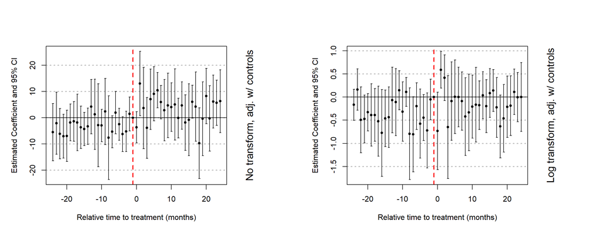

### 3.1.5 Total Payments

**Outcome: baseline**

|  | No Transformation |  | Log Transformed |  |
| --- | --- | --- | --- | --- |
|  | (1) | (2) | (3) | (4) |
| Rec_disp | 61,748.830** | 62,776.720** | 0.438 | 0.412 |
|  | (28,904.760) | (25,605.100) | (0.267) | (0.325) |
| Rec_eff |  | -20,023.710 |  | -0.147 |
|  |  | (17,861.800) |  | (0.185) |
| Med_disp |  | 5,711.597 |  | 0.323* |
|  |  | (16,253.570) |  | (0.190) |
| Med_eff |  | -7,604.428 |  | 0.201 |
|  |  | (9,041.267) |  | (0.199) |
| Spillover |  | -8,936.492 |  | -0.049 |
|  |  | (6,367.264) |  | (0.092) |
| Population |  | 0.014 |  | 0.00000 |
|  |  | (0.014) |  | (0.00000) |
| Age |  | 319,823.700** |  | 6.841** |
|  |  | (157,951.400) |  | (2.909) |
| Gender |  | -399,396.900 |  | -0.348 |
|  |  | (351,337.000) |  | (9.517) |
| Race |  | -1,025.595 |  | 0.826 |
|  |  | (92,914.940) |  | (1.504) |
| MDI |  | 6,563.409 |  | 0.171* |
|  |  | (4,915.841) |  | (0.099) |
| Employment |  | -206,187.400*** |  | -5.587* |
|  |  | (55,257.030) |  | (2.872) |
| Industry |  | 14,095.900 |  | 2.078 |
|  |  | (69,477.990) |  | (1.799) |
| Insurance_plan |  | -124,284.600** |  | -0.721 |
|  |  | (49,724.440) |  | (0.502) |
| Days_abs |  | -0.0003 |  | -0.00000** |
|  |  | (0.0002) |  | (0.000) |
| MHD |  | 9.754* |  | 0.0004* |
|  |  | (5.389) |  | (0.0002) |
| AUD |  | 53.702 |  | 0.002 |
|  |  | (93.183) |  | (0.001) |
| Healthcare_exp |  | 26.835* |  | 0.0005 |
|  |  | (15.386) |  | (0.0003) |
| Hospitals |  | -42,143.460 |  | 0.234 |
|  |  | (28,094.780) |  | (0.579) |
| Officers |  | -14,759.110 |  | -0.180 |
|  |  | (16,772.310) |  | (0.225) |
| Crime |  | 0.128 |  | -0.00003 |
|  |  | (4.237) |  | (0.0001) |
| Drug_seize |  | -13.947 |  | -0.002 |
|  |  | (222.644) |  | (0.003) |
| Mandate_covid |  | 3,485.784 |  | -0.214 |
|  |  | (17,955.190) |  | (0.282) |
| Controls | No | Yes | No | Yes |
| FE: State/Year | Yes | Yes | Yes | Yes |
| Observations | 3,741 | 3,741 | 3,741 | 3,741 |
| R<sup>2</sup> | 0.178 | 0.195 | 0.512 | 0.662 |
| Adjusted R<sup>2</sup> | 0.148 | 0.162 | 0.495 | 0.647 |
| *Note:* | p<0.1; p<0.05; p<0.01 |  |  |  |
|  | Robust standard errors are clustered at the state level |  |  |  |

**Outcome: lead (6 months)**

|  | No Transformation |  | Log Transformed |  |
| --- | --- | --- | --- | --- |
|  | (1) | (2) | (3) | (4) |
| Rec_disp | 55,832.990** | 58,851.970** | 0.477* | 0.518 |
|  | (25,053.520) | (22,517.290) | (0.279) | (0.317) |
| Rec_eff |  | -23,776.540 |  | -0.016 |
|  |  | (16,812.860) |  | (0.209) |
| Med_disp |  | 8,935.773 |  | 0.329* |
|  |  | (15,198.110) |  | (0.176) |
| Med_eff |  | -23,971.720 |  | 0.082 |
|  |  | (14,461.600) |  | (0.173) |
| Spillover |  | -8,315.027 |  | -0.051 |
|  |  | (6,181.708) |  | (0.094) |
| Population |  | 0.012 |  | 0.00000 |
|  |  | (0.021) |  | (0.00000) |
| Age |  | 263,650.800* |  | 12.627*** |
|  |  | (151,947.000) |  | (4.474) |
| Gender |  | -164,434.300 |  | 4.157 |
|  |  | (300,276.100) |  | (8.676) |
| Race |  | 48,341.180 |  | 0.044 |
|  |  | (149,127.300) |  | (2.045) |
| MDI |  | 10,730.470** |  | 0.244** |
|  |  | (4,784.664) |  | (0.109) |
| Employment |  | -210,037.100*** |  | -7.574** |
|  |  | (74,923.730) |  | (3.567) |
| Industry |  | -35,520.290 |  | 1.766 |
|  |  | (65,050.340) |  | (1.691) |
| Insurance_plan |  | -141,198.500** |  | -0.151 |
|  |  | (53,226.260) |  | (0.754) |
| Days_abs |  | -0.001*** |  | -0.00000*** |
|  |  | (0.0003) |  | (0.000) |
| MHD |  | 2.552 |  | 0.0003* |
|  |  | (6.333) |  | (0.0002) |
| AUD |  | 8.866 |  | 0.0003 |
|  |  | (65.590) |  | (0.001) |
| Healthcare_exp |  | 27.339* |  | 0.0004 |
|  |  | (15.767) |  | (0.0003) |
| Hospitals |  | 27,830.550 |  | 0.678 |
|  |  | (43,717.700) |  | (0.607) |
| Officers |  | 17,546.660 |  | 0.091 |
|  |  | (27,477.680) |  | (0.298) |
| Crime |  | 13.714*** |  | 0.00002 |
|  |  | (4.360) |  | (0.00005) |
| Drug_seize |  | 185.906 |  | 0.002 |
|  |  | (273.749) |  | (0.003) |
| Mandate_covid |  | -1,235.103 |  | -0.350 |
|  |  | (21,292.890) |  | (0.260) |
| Controls | No | Yes | No | Yes |
| FE: State/Year | Yes | Yes | Yes | Yes |
| Observations | 3,483 | 3,483 | 3,483 | 3,483 |
| R<sup>2</sup> | 0.164 | 0.175 | 0.503 | 0.606 |
| Adjusted R<sup>2</sup> | 0.133 | 0.140 | 0.485 | 0.589 |
| *Note:* | p<0.1; p<0.05; p<0.01 |  |  |  |
|  | Robust standard errors are clustered at the state level |  |  |  |

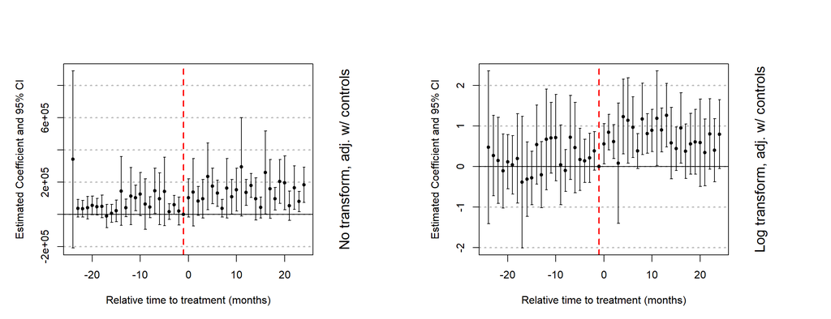

## 3.2 Outcomes related to OUD

### 3.2.1 Prevalence

**Outcome: baseline**

|  | No Transformation |  | Log Transformed |  |
| --- | --- | --- | --- | --- |
|  | (1) | (2) | (3) | (4) |
| Rec_disp | 20.858 | -0.251 | 0.098 | -0.070 |
|  | (40.320) | (29.867) | (0.159) | (0.093) |
| Rec_eff |  | -11.008 |  | 0.059 |
|  |  | (27.479) |  | (0.074) |
| Med_disp |  | -59.364** |  | -0.111 |
|  |  | (28.279) |  | (0.097) |
| Med_eff |  | 13.793 |  | 0.096 |
|  |  | (26.752) |  | (0.094) |
| Spillover |  | 30.736* |  | 0.056 |
|  |  | (15.936) |  | (0.046) |
| Population |  | -0.00003 |  | -0.000 |
|  |  | (0.00003) |  | (0.00000) |
| Age |  | -136.192 |  | -1.229 |
|  |  | (183.317) |  | (0.757) |
| Gender |  | -727.137** |  | -4.721** |
|  |  | (325.219) |  | (2.134) |
| Race |  | -325.417 |  | -0.616 |
|  |  | (227.598) |  | (1.015) |
| MDI |  | -12.437 |  | -0.053* |
|  |  | (8.756) |  | (0.027) |
| Employment |  | 45.566 |  | 0.451 |
|  |  | (129.242) |  | (0.430) |
| Industry |  | 174.934** |  | -0.073 |
|  |  | (80.824) |  | (0.519) |
| Insurance_plan |  | 26.092 |  | -0.050 |
|  |  | (84.103) |  | (0.407) |
| Days_abs |  | -0.00000 |  | -0.000* |
|  |  | (0.00000) |  | (0.000) |
| MHD |  | 0.022*** |  | 0.0001*** |
|  |  | (0.007) |  | (0.00003) |
| AUD |  | 0.183** |  | 0.001*** |
|  |  | (0.081) |  | (0.0002) |
| Healthcare_exp |  | 0.034 |  | -0.00002 |
|  |  | (0.032) |  | (0.0001) |
| Hospitals |  | -14.670 |  | 0.019 |
|  |  | (65.240) |  | (0.278) |
| Officers |  | -6.221 |  | 0.037 |
|  |  | (49.991) |  | (0.155) |
| Crime |  | -0.017 |  | -0.00004 |
|  |  | (0.015) |  | (0.00003) |
| Drug_seize |  | 1.013*** |  | 0.004*** |
|  |  | (0.353) |  | (0.001) |
| Mandate_covid |  | 16.833 |  | -0.136 |
|  |  | (32.817) |  | (0.144) |
| Controls | No | Yes | No | Yes |
| FE: State/Year | Yes | Yes | Yes | Yes |
| Observations | 3,741 | 3,741 | 3,741 | 3,741 |
| R<sup>2</sup> | 0.764 | 0.850 | 0.568 | 0.789 |
| Adjusted R<sup>2</sup> | 0.755 | 0.844 | 0.552 | 0.780 |
| *Note:* | p<0.1; p<0.05; p<0.01 |  |  |  |
|  | Robust standard errors are clustered at the state level |  |  |  |

**Outcome: lead (6 months)**

|  | No Transformation |  | Log Transformed |  |
| --- | --- | --- | --- | --- |
|  | (1) | (2) | (3) | (4) |
| Rec_disp | 14.620 | 1.887 | 0.083 | -0.055 |
|  | (33.950) | (27.644) | (0.134) | (0.105) |
| Rec_eff |  | 19.590 |  | 0.208 |
|  |  | (28.578) |  | (0.132) |
| Med_disp |  | -47.267* |  | -0.118 |
|  |  | (26.734) |  | (0.089) |
| Med_eff |  | -4.829 |  | 0.087 |
|  |  | (23.980) |  | (0.112) |
| Spillover |  | 20.577 |  | 0.021 |
|  |  | (13.979) |  | (0.051) |
| Population |  | 0.00001 |  | 0.00000 |
|  |  | (0.00003) |  | (0.00000) |
| Age |  | 339.506 |  | 0.947 |
|  |  | (374.018) |  | (2.043) |
| Gender |  | -934.749** |  | -4.713* |
|  |  | (460.208) |  | (2.412) |
| Race |  | -392.076* |  | -0.679 |
|  |  | (225.824) |  | (1.216) |
| MDI |  | 2.612 |  | -0.0003 |
|  |  | (15.346) |  | (0.058) |
| Employment |  | -58.157 |  | -0.204 |
|  |  | (132.697) |  | (0.435) |
| Industry |  | 150.270 |  | 0.066 |
|  |  | (97.668) |  | (0.515) |
| Insurance_plan |  | 38.394 |  | -0.022 |
|  |  | (119.612) |  | (0.571) |
| Days_abs |  | -0.00000* |  | -0.000** |
|  |  | (0.00000) |  | (0.000) |
| MHD |  | 0.015* |  | 0.0001* |
|  |  | (0.008) |  | (0.00004) |
| AUD |  | 0.120* |  | 0.0003 |
|  |  | (0.060) |  | (0.0003) |
| Healthcare_exp |  | 0.010 |  | -0.0002 |
|  |  | (0.023) |  | (0.0002) |
| Hospitals |  | 9.442 |  | 0.117 |
|  |  | (55.121) |  | (0.243) |
| Officers |  | -15.006 |  | 0.054 |
|  |  | (58.085) |  | (0.190) |
| Crime |  | -0.015 |  | -0.00004 |
|  |  | (0.010) |  | (0.00003) |
| Drug_seize |  | 1.051*** |  | 0.005*** |
|  |  | (0.360) |  | (0.001) |
| Mandate_covid |  | 6.702 |  | -0.200 |
|  |  | (32.103) |  | (0.173) |
| Controls | No | Yes | No | Yes |
| FE: State/Year | Yes | Yes | Yes | Yes |
| Observations | 3,483 | 3,483 | 3,483 | 3,483 |
| R<sup>2</sup> | 0.769 | 0.818 | 0.560 | 0.674 |
| Adjusted R<sup>2</sup> | 0.761 | 0.810 | 0.544 | 0.660 |
| *Note:* | p<0.1; p<0.05; p<0.01 |  |  |  |
|  | Robust standard errors are clustered at the state level |  |  |  |

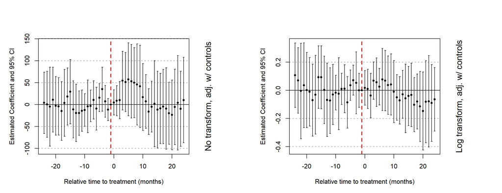

### 3.2.2 IP Admissions

**Outcome: baseline**

|  | No Transformation |  | Log Transformed |  |
| --- | --- | --- | --- | --- |
|  | (1) | (2) | (3) | (4) |
| Rec_disp | 0.339 | -0.286 | 0.108 | 0.067 |
|  | (1.441) | (1.506) | (0.127) | (0.135) |
| Rec_eff |  | 1.242 |  | 0.027 |
|  |  | (1.446) |  | (0.098) |
| Med_disp |  | -0.772 |  | 0.041 |
|  |  | (0.742) |  | (0.069) |
| Med_eff |  | -0.337 |  | -0.008 |
|  |  | (0.809) |  | (0.078) |
| Spillover |  | 0.236 |  | 0.045 |
|  |  | (0.336) |  | (0.035) |
| Population |  | 0.00000** |  | 0.00000** |
|  |  | (0.00000) |  | (0.00000) |
| Age |  | 10.585* |  | 1.775*** |
|  |  | (5.808) |  | (0.606) |
| Gender |  | -15.643 |  | -0.764 |
|  |  | (16.481) |  | (2.159) |
| Race |  | -5.448 |  | -0.607 |
|  |  | (7.759) |  | (0.651) |
| MDI |  | -0.363 |  | -0.016 |
|  |  | (0.271) |  | (0.027) |
| Employment |  | -6.521 |  | -1.473*** |
|  |  | (3.962) |  | (0.428) |
| Industry |  | 2.982 |  | 0.600 |
|  |  | (3.484) |  | (0.427) |
| Insurance_plan |  | -2.577 |  | -0.395 |
|  |  | (3.202) |  | (0.270) |
| Days_abs |  | -0.00000** |  | -0.000** |
|  |  | (0.000) |  | (0.000) |
| MHD |  | 0.0002 |  | 0.0001 |
|  |  | (0.0003) |  | (0.00005) |
| AUD |  | 0.004 |  | 0.001 |
|  |  | (0.004) |  | (0.001) |
| Healthcare_exp |  | 0.002** |  | 0.0002** |
|  |  | (0.001) |  | (0.0001) |
| Hospitals |  | 3.307 |  | 0.414** |
|  |  | (1.998) |  | (0.162) |
| Officers |  | 0.935 |  | 0.146 |
|  |  | (1.533) |  | (0.138) |
| Crime |  | 0.00000 |  | -0.00000 |
|  |  | (0.0003) |  | (0.00003) |
| Drug_seize |  | -0.013 |  | -0.0003 |
|  |  | (0.013) |  | (0.001) |
| Mandate_covid |  | -1.731* |  | 0.002 |
|  |  | (0.929) |  | (0.103) |
| Controls | No | Yes | No | Yes |
| FE: State/Year | Yes | Yes | Yes | Yes |
| Observations | 3,741 | 3,741 | 3,741 | 3,741 |
| R<sup>2</sup> | 0.363 | 0.399 | 0.477 | 0.538 |
| Adjusted R<sup>2</sup> | 0.340 | 0.373 | 0.458 | 0.519 |
| *Note:* | p<0.1; p<0.05; p<0.01 |  |  |  |
|  | Robust standard errors are clustered at the state level |  |  |  |

**Outcome: lead (6 months)**

|  | No Transformation |  | Log Transformed |  |
| --- | --- | --- | --- | --- |
|  | (1) | (2) | (3) | (4) |
| Rec_disp | 0.194 | -0.106 | 0.078 | 0.051 |
|  | (1.219) | (1.269) | (0.120) | (0.133) |
| Rec_eff |  | 0.754 |  | 0.061 |
|  |  | (0.792) |  | (0.087) |
| Med_disp |  | -1.142 |  | 0.005 |
|  |  | (0.833) |  | (0.068) |
| Med_eff |  | -0.446 |  | -0.047 |
|  |  | (0.749) |  | (0.106) |
| Spillover |  | 0.347 |  | 0.049 |
|  |  | (0.292) |  | (0.033) |
| Population |  | 0.00000*** |  | 0.00000*** |
|  |  | (0.00000) |  | (0.00000) |
| Age |  | 21.584** |  | 3.438*** |
|  |  | (9.036) |  | (1.141) |
| Gender |  | -2.457 |  | 0.736 |
|  |  | (19.378) |  | (2.175) |
| Race |  | -7.094 |  | -1.082 |
|  |  | (5.572) |  | (0.673) |
| MDI |  | -0.322 |  | -0.016 |
|  |  | (0.324) |  | (0.036) |
| Employment |  | -8.378** |  | -1.635** |
|  |  | (4.080) |  | (0.655) |
| Industry |  | 3.473 |  | 0.543 |
|  |  | (3.746) |  | (0.445) |
| Insurance_plan |  | 0.362 |  | -0.128 |
|  |  | (3.109) |  | (0.298) |
| Days_abs |  | -0.00000*** |  | -0.000*** |
|  |  | (0.00000) |  | (0.000) |
| MHD |  | 0.0002 |  | 0.0001 |
|  |  | (0.0004) |  | (0.00004) |
| AUD |  | -0.0001 |  | 0.0002 |
|  |  | (0.003) |  | (0.0004) |
| Healthcare_exp |  | 0.002** |  | 0.0002** |
|  |  | (0.001) |  | (0.0001) |
| Hospitals |  | 3.850** |  | 0.511*** |
|  |  | (1.672) |  | (0.176) |
| Officers |  | 0.471 |  | 0.041 |
|  |  | (0.998) |  | (0.094) |
| Crime |  | 0.0001 |  | -0.00000 |
|  |  | (0.0002) |  | (0.00003) |
| Drug_seize |  | -0.006 |  | 0.0002 |
|  |  | (0.016) |  | (0.001) |
| Mandate_covid |  | -1.522* |  | -0.039 |
|  |  | (0.861) |  | (0.092) |
| Controls | No | Yes | No | Yes |
| FE: State/Year | Yes | Yes | Yes | Yes |
| Observations | 3,483 | 3,483 | 3,483 | 3,483 |
| R<sup>2</sup> | 0.354 | 0.380 | 0.472 | 0.516 |
| Adjusted R<sup>2</sup> | 0.330 | 0.353 | 0.452 | 0.495 |
| *Note:* | p<0.1; p<0.05; p<0.01 |  |  |  |
|  | Robust standard errors are clustered at the state level |  |  |  |

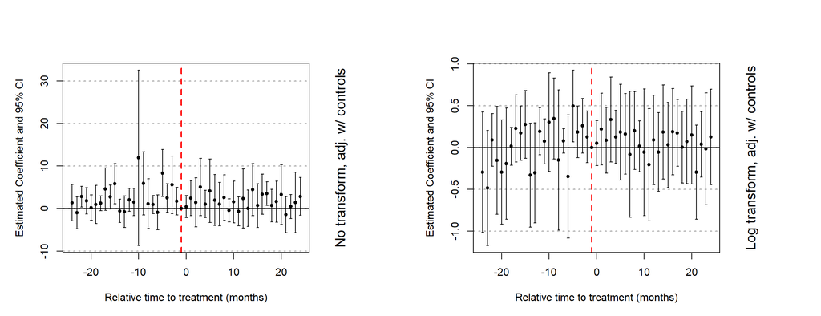

### 3.2.3 LOS

**Outcome: baseline**

|  | No Transformation |  | Log Transformed |  |
| --- | --- | --- | --- | --- |
|  | (1) | (2) | (3) | (4) |
| Rec_disp | 14.515 | 13.478 | 0.309 | 0.269 |
|  | (16.006) | (17.846) | (0.219) | (0.246) |
| Rec_eff |  | -1.772 |  | -0.042 |
|  |  | (8.045) |  | (0.129) |
| Med_disp |  | -6.536 |  | 0.114 |
|  |  | (6.232) |  | (0.114) |
| Med_eff |  | -0.556 |  | 0.004 |
|  |  | (4.666) |  | (0.117) |
| Spillover |  | 1.736 |  | 0.092 |
|  |  | (2.548) |  | (0.060) |
| Population |  | 0.00001 |  | 0.00000 |
|  |  | (0.00001) |  | (0.00000) |
| Age |  | 64.041 |  | 2.535** |
|  |  | (60.900) |  | (1.071) |
| Gender |  | -44.222 |  | 0.565 |
|  |  | (133.706) |  | (3.476) |
| Race |  | -76.670* |  | -1.589 |
|  |  | (45.506) |  | (1.009) |
| MDI |  | -0.591 |  | -0.001 |
|  |  | (2.161) |  | (0.038) |
| Employment |  | -107.769*** |  | -3.043*** |
|  |  | (31.445) |  | (0.889) |
| Industry |  | 17.965 |  | 0.820 |
|  |  | (22.170) |  | (0.618) |
| Insurance_plan |  | -28.865 |  | -0.517 |
|  |  | (24.390) |  | (0.363) |
| Days_abs |  | -0.00000*** |  | -0.000*** |
|  |  | (0.00000) |  | (0.000) |
| MHD |  | 0.001 |  | 0.0001* |
|  |  | (0.002) |  | (0.0001) |
| AUD |  | 0.040 |  | 0.001 |
|  |  | (0.028) |  | (0.001) |
| Healthcare_exp |  | 0.006 |  | 0.0002 |
|  |  | (0.005) |  | (0.0001) |
| Hospitals |  | 12.947 |  | 0.424 |
|  |  | (10.395) |  | (0.278) |
| Officers |  | -3.192 |  | -0.024 |
|  |  | (7.847) |  | (0.171) |
| Crime |  | -0.001 |  | -0.00002 |
|  |  | (0.002) |  | (0.00005) |
| Drug_seize |  | 0.064 |  | 0.001 |
|  |  | (0.088) |  | (0.002) |
| Mandate_covid |  | -4.795 |  | 0.169 |
|  |  | (7.515) |  | (0.159) |
| Controls | No | Yes | No | Yes |
| FE: State/Year | Yes | Yes | Yes | Yes |
| Observations | 3,741 | 3,741 | 3,741 | 3,741 |
| R<sup>2</sup> | 0.301 | 0.340 | 0.481 | 0.547 |
| Adjusted R<sup>2</sup> | 0.276 | 0.313 | 0.462 | 0.528 |
| *Note:* | p<0.1; p<0.05; p<0.01 |  |  |  |
|  | Robust standard errors are clustered at the state level |  |  |  |

**Outcome: lead (6 months)**

|  | No Transformation |  | Log Transformed |  |
| --- | --- | --- | --- | --- |
|  | (1) | (2) | (3) | (4) |
| Rec_disp | 7.507 | 4.855 | 0.210 | 0.161 |
|  | (14.088) | (15.789) | (0.221) | (0.266) |
| Rec_eff |  | 4.530 |  | 0.084 |
|  |  | (7.970) |  | (0.156) |
| Med_disp |  | -8.832 |  | 0.045 |
|  |  | (6.923) |  | (0.116) |
| Med_eff |  | -2.512 |  | -0.050 |
|  |  | (5.433) |  | (0.175) |
| Spillover |  | 1.404 |  | 0.089 |
|  |  | (2.492) |  | (0.059) |
| Population |  | 0.00001 |  | 0.00000 |
|  |  | (0.00001) |  | (0.00000) |
| Age |  | 174.626** |  | 5.512*** |
|  |  | (80.409) |  | (1.978) |
| Gender |  | 10.448 |  | 2.875 |
|  |  | (92.211) |  | (2.709) |
| Race |  | -117.044** |  | -2.673* |
|  |  | (55.024) |  | (1.333) |
| MDI |  | 0.023 |  | -0.001 |
|  |  | (2.288) |  | (0.056) |
| Employment |  | -93.618** |  | -3.126** |
|  |  | (35.569) |  | (1.242) |
| Industry |  | 9.350 |  | 0.617 |
|  |  | (14.321) |  | (0.564) |
| Insurance_plan |  | -2.819 |  | -0.175 |
|  |  | (19.827) |  | (0.399) |
| Days_abs |  | -0.00000*** |  | -0.00000*** |
|  |  | (0.00000) |  | (0.000) |
| MHD |  | -0.001 |  | 0.0001 |
|  |  | (0.002) |  | (0.0001) |
| AUD |  | 0.026* |  | 0.0004 |
|  |  | (0.015) |  | (0.0005) |
| Healthcare_exp |  | 0.008 |  | 0.0001 |
|  |  | (0.006) |  | (0.0001) |
| Hospitals |  | 23.219** |  | 0.608* |
|  |  | (10.713) |  | (0.308) |
| Officers |  | -6.439 |  | -0.156 |
|  |  | (7.315) |  | (0.203) |
| Crime |  | 0.0004 |  | -0.00002 |
|  |  | (0.002) |  | (0.00005) |
| Drug_seize |  | 0.085 |  | 0.002 |
|  |  | (0.106) |  | (0.002) |
| Mandate_covid |  | -1.468 |  | 0.082 |
|  |  | (7.556) |  | (0.158) |
| Controls | No | Yes | No | Yes |
| FE: State/Year | Yes | Yes | Yes | Yes |
| Observations | 3,483 | 3,483 | 3,483 | 3,483 |
| R<sup>2</sup> | 0.303 | 0.334 | 0.480 | 0.526 |
| Adjusted R<sup>2</sup> | 0.277 | 0.305 | 0.460 | 0.506 |
| *Note:* | p<0.1; p<0.05; p<0.01 |  |  |  |
|  | Robust standard errors are clustered at the state level |  |  |  |

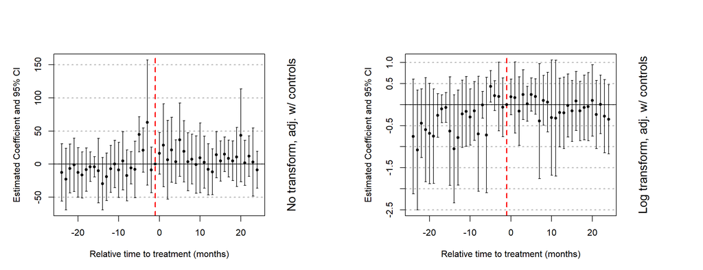

### 3.2.4 ER Visits

**Outcome: baseline**

|  | No Transformation |  | Log Transformed |  |
| --- | --- | --- | --- | --- |
|  | (1) | (2) | (3) | (4) |
| Rec_disp | -13.009 | -16.210 | -0.006 | -0.067 |
|  | (8.217) | (10.725) | (0.187) | (0.170) |
| Rec_eff |  | -7.066 |  | -0.109 |
|  |  | (14.941) |  | (0.122) |
| Med_disp |  | 2.672 |  | 0.091 |
|  |  | (11.089) |  | (0.135) |
| Med_eff |  | 6.503 |  | 0.033 |
|  |  | (13.795) |  | (0.200) |
| Spillover |  | 2.537 |  | 0.092 |
|  |  | (4.139) |  | (0.069) |
| Population |  | -0.00000 |  | 0.00000* |
|  |  | (0.00001) |  | (0.00000) |
| Age |  | -122.005 |  | 0.605 |
|  |  | (125.408) |  | (1.417) |
| Gender |  | -134.000 |  | 0.711 |
|  |  | (119.093) |  | (2.515) |
| Race |  | -13.452 |  | -1.326 |
|  |  | (79.419) |  | (1.415) |
| MDI |  | -7.216** |  | -0.074 |
|  |  | (2.749) |  | (0.051) |
| Employment |  | -4.195 |  | -0.819 |
|  |  | (36.808) |  | (0.969) |
| Industry |  | 54.921 |  | 0.969 |
|  |  | (40.964) |  | (0.746) |
| Insurance_plan |  | 61.641** |  | 1.018* |
|  |  | (29.004) |  | (0.571) |
| Days_abs |  | -0.00000 |  | -0.000** |
|  |  | (0.00000) |  | (0.000) |
| MHD |  | 0.007*** |  | 0.0002*** |
|  |  | (0.002) |  | (0.0001) |
| AUD |  | 0.046** |  | 0.002*** |
|  |  | (0.018) |  | (0.0005) |
| Healthcare_exp |  | 0.004 |  | 0.0002 |
|  |  | (0.014) |  | (0.0002) |
| Hospitals |  | -10.135 |  | -0.111 |
|  |  | (17.239) |  | (0.294) |
| Officers |  | -8.629 |  | -0.334* |
|  |  | (15.339) |  | (0.192) |
| Crime |  | -0.003 |  | -0.00004 |
|  |  | (0.003) |  | (0.00004) |
| Drug_seize |  | 0.119 |  | 0.004* |
|  |  | (0.174) |  | (0.002) |
| Mandate_covid |  | -0.958 |  | -0.098 |
|  |  | (12.084) |  | (0.223) |
| Controls | No | Yes | No | Yes |
| FE: State/Year | Yes | Yes | Yes | Yes |
| Observations | 3,741 | 3,741 | 3,741 | 3,741 |
| R<sup>2</sup> | 0.566 | 0.635 | 0.589 | 0.671 |
| Adjusted R<sup>2</sup> | 0.551 | 0.620 | 0.574 | 0.657 |
| *Note:* | p<0.1; p<0.05; p<0.01 |  |  |  |
|  | Robust standard errors are clustered at the state level |  |  |  |

**Outcome: lead (6 months)**

|  | No Transformation |  | Log Transformed |  |
| --- | --- | --- | --- | --- |
|  | (1) | (2) | (3) | (4) |
| Rec_disp | -12.735 | -14.806 | -0.055 | -0.142 |
|  | (8.102) | (10.907) | (0.182) | (0.179) |
| Rec_eff |  | -0.888 |  | 0.147 |
|  |  | (11.716) |  | (0.144) |
| Med_disp |  | 3.672 |  | 0.070 |
|  |  | (11.549) |  | (0.141) |
| Med_eff |  | -1.268 |  | -0.096 |
|  |  | (11.119) |  | (0.180) |
| Spillover |  | -0.765 |  | 0.022 |
|  |  | (3.498) |  | (0.058) |
| Population |  | 0.00001 |  | 0.00000** |
|  |  | (0.00001) |  | (0.00000) |
| Age |  | -11.815 |  | 3.037 |
|  |  | (74.020) |  | (1.942) |
| Gender |  | -197.872 |  | -0.097 |
|  |  | (121.871) |  | (3.104) |
| Race |  | -14.369 |  | -1.657 |
|  |  | (82.816) |  | (1.423) |
| MDI |  | 0.223 |  | 0.032 |
|  |  | (3.091) |  | (0.065) |
| Employment |  | -9.599 |  | -1.287 |
|  |  | (39.279) |  | (1.130) |
| Industry |  | 26.810 |  | 0.759 |
|  |  | (41.063) |  | (0.734) |
| Insurance_plan |  | 63.522** |  | 1.279* |
|  |  | (31.010) |  | (0.754) |
| Days_abs |  | -0.00000 |  | -0.000*** |
|  |  | (0.00000) |  | (0.000) |
| MHD |  | 0.005* |  | 0.0001** |
|  |  | (0.003) |  | (0.00005) |
| AUD |  | 0.032* |  | 0.001*** |
|  |  | (0.016) |  | (0.0004) |
| Healthcare_exp |  | 0.0002 |  | 0.0001 |
|  |  | (0.012) |  | (0.0002) |
| Hospitals |  | 2.892 |  | 0.239 |
|  |  | (18.427) |  | (0.378) |
| Officers |  | 1.289 |  | -0.210 |
|  |  | (23.560) |  | (0.243) |
| Crime |  | 0.001 |  | 0.00003 |
|  |  | (0.003) |  | (0.00004) |
| Drug_seize |  | 0.082 |  | 0.005* |
|  |  | (0.203) |  | (0.003) |
| Mandate_covid |  | 4.188 |  | -0.238 |
|  |  | (9.794) |  | (0.206) |
| Controls | No | Yes | No | Yes |
| FE: State/Year | Yes | Yes | Yes | Yes |
| Observations | 3,483 | 3,483 | 3,483 | 3,483 |
| R<sup>2</sup> | 0.579 | 0.612 | 0.599 | 0.646 |
| Adjusted R<sup>2</sup> | 0.564 | 0.595 | 0.585 | 0.631 |
| *Note:* | p<0.1; p<0.05; p<0.01 |  |  |  |
|  | Robust standard errors are clustered at the state level |  |  |  |

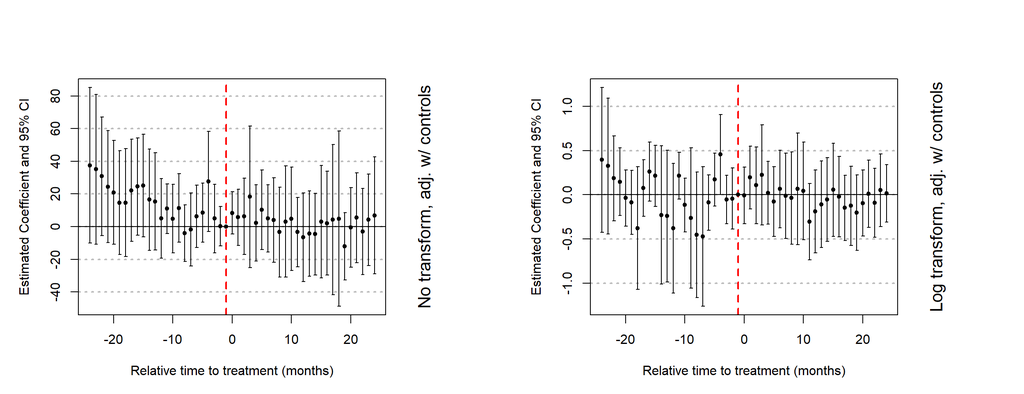

### 3.2.5 Total Payments

**Outcome: baseline**

|  | No Transformation |  | Log Transformed |  |
| --- | --- | --- | --- | --- |
|  | (1) | (2) | (3) | (4) |
| Rec_disp | 90,213.170 | 91,355.190 | 0.412* | 0.227 |
|  | (98,764.960) | (106,972.600) | (0.226) | (0.202) |
| Rec_eff |  | -8,691.900 |  | -0.012 |
|  |  | (40,782.660) |  | (0.109) |
| Med_disp |  | -32,537.910 |  | 0.140 |
|  |  | (25,279.790) |  | (0.136) |
| Med_eff |  | -11,421.100 |  | 0.043 |
|  |  | (26,073.450) |  | (0.159) |
| Spillover |  | 10,564.820 |  | 0.098 |
|  |  | (12,008.160) |  | (0.063) |
| Population |  | 0.058 |  | 0.00000 |
|  |  | (0.044) |  | (0.00000) |
| Age |  | 475,717.800* |  | -0.492 |
|  |  | (273,133.600) |  | (1.600) |
| Gender |  | -263,601.300 |  | -6.444 |
|  |  | (706,239.700) |  | (5.066) |
| Race |  | -448,904.900 |  | 0.074 |
|  |  | (278,175.300) |  | (1.518) |
| MDI |  | -65.433 |  | -0.030 |
|  |  | (7,752.112) |  | (0.041) |
| Employment |  | -341,743.200** |  | -1.147 |
|  |  | (162,917.500) |  | (0.952) |
| Industry |  | 21,984.560 |  | -0.603 |
|  |  | (109,354.600) |  | (0.915) |
| Insurance_plan |  | -45,061.480 |  | -0.784 |
|  |  | (129,809.000) |  | (0.615) |
| Days_abs |  | -0.001** |  | -0.00000** |
|  |  | (0.001) |  | (0.000) |
| MHD |  | 12.251 |  | 0.0002** |
|  |  | (11.514) |  | (0.0001) |
| AUD |  | 144.180 |  | 0.002*** |
|  |  | (156.415) |  | (0.0003) |
| Healthcare_exp |  | 63.092* |  | 0.00002 |
|  |  | (31.410) |  | (0.0001) |
| Hospitals |  | 13,340.000 |  | 0.199 |
|  |  | (57,819.100) |  | (0.341) |
| Officers |  | -7,985.212 |  | -0.0002 |
|  |  | (34,347.650) |  | (0.140) |
| Crime |  | -5.523 |  | -0.00003 |
|  |  | (12.465) |  | (0.0001) |
| Drug_seize |  | -206.243 |  | 0.003 |
|  |  | (397.626) |  | (0.002) |
| Mandate_covid |  | -25,744.890 |  | -0.129 |
|  |  | (33,431.680) |  | (0.177) |
| Controls | No | Yes | No | Yes |
| FE: State/Year | Yes | Yes | Yes | Yes |
| Observations | 3,741 | 3,741 | 3,741 | 3,741 |
| R<sup>2</sup> | 0.196 | 0.216 | 0.364 | 0.614 |
| Adjusted R<sup>2</sup> | 0.167 | 0.183 | 0.341 | 0.597 |
| *Note:* | p<0.1; p<0.05; p<0.01 |  |  |  |
|  | Robust standard errors are clustered at the state level |  |  |  |

**Outcome: lead (6 months)**

|  | No Transformation |  | Log Transformed |  |
| --- | --- | --- | --- | --- |
|  | (1) | (2) | (3) | (4) |
| Rec_disp | 31,544.930 | 23,192.400 | 0.314 | 0.175 |
|  | (68,089.400) | (76,042.020) | (0.216) | (0.238) |
| Rec_eff |  | 36,353.460 |  | 0.246 |
|  |  | (46,816.220) |  | (0.233) |
| Med_disp |  | -38,906.290 |  | 0.067 |
|  |  | (25,415.610) |  | (0.109) |
| Med_eff |  | -5,546.335 |  | 0.099 |
|  |  | (26,527.600) |  | (0.171) |
| Spillover |  | 2,998.878 |  | 0.058 |
|  |  | (10,751.880) |  | (0.074) |
| Population |  | 0.071 |  | 0.00000 |
|  |  | (0.042) |  | (0.00000) |
| Age |  | 795,387.000** |  | 3.600 |
|  |  | (370,332.400) |  | (3.860) |
| Gender |  | 89,318.120 |  | -2.035 |
|  |  | (662,717.400) |  | (4.322) |
| Race |  | -476,628.700 |  | -0.894 |
|  |  | (327,176.000) |  | (2.117) |
| MDI |  | 24,952.220** |  | 0.049 |
|  |  | (12,339.300) |  | (0.083) |
| Employment |  | -347,587.900 |  | -1.868** |
|  |  | (209,525.700) |  | (0.899) |
| Industry |  | 55,622.560 |  | -0.275 |
|  |  | (108,760.200) |  | (0.811) |
| Insurance_plan |  | 25,628.280 |  | -0.183 |
|  |  | (109,394.600) |  | (0.962) |
| Days_abs |  | -0.003** |  | -0.00000*** |
|  |  | (0.001) |  | (0.000) |
| MHD |  | 8.289 |  | 0.0001** |
|  |  | (14.703) |  | (0.0001) |
| AUD |  | -20.896 |  | 0.0002 |
|  |  | (154.905) |  | (0.001) |
| Healthcare_exp |  | 59.275* |  | -0.0002 |
|  |  | (33.308) |  | (0.0003) |
| Hospitals |  | 99,298.420* |  | 0.555* |
|  |  | (58,399.330) |  | (0.307) |
| Officers |  | 8,411.789 |  | 0.022 |
|  |  | (31,483.040) |  | (0.204) |
| Crime |  | 17.475 |  | -0.00001 |
|  |  | (15.228) |  | (0.00004) |
| Drug_seize |  | 154.858 |  | 0.005* |
|  |  | (519.962) |  | (0.003) |
| Mandate_covid |  | -1,007.387 |  | -0.319 |
|  |  | (36,758.240) |  | (0.221) |
| Controls | No | Yes | No | Yes |
| FE: State/Year | Yes | Yes | Yes | Yes |
| Observations | 3,483 | 3,483 | 3,483 | 3,483 |
| R<sup>2</sup> | 0.193 | 0.209 | 0.362 | 0.490 |
| Adjusted R<sup>2</sup> | 0.164 | 0.175 | 0.338 | 0.468 |
| *Note:* | p<0.1; p<0.05; p<0.01 |  |  |  |
|  | Robust standard errors are clustered at the state level |  |  |  |

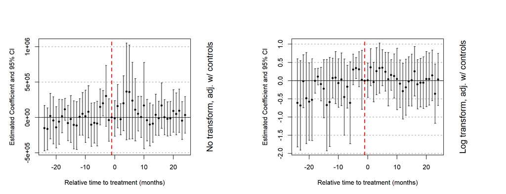

## 3.3 Outcomes related to Prescriptions

### 3.3.1 Opioids: Total Days of Supply

**Outcome: baseline**

|  | No Transformation |  | Log Transformed |  |
| --- | --- | --- | --- | --- |
|  | (1) | (2) | (3) | (4) |
| Rec_disp | -9,274.933 | -6,597.732 | -0.012 | -0.094 |
|  | (12,592.460) | (6,500.472) | (0.107) | (0.061) |
| Rec_eff |  | -14,707.660 |  | -0.102 |
|  |  | (11,634.890) |  | (0.079) |
| Med_disp |  | -408.987 |  | 0.003 |
|  |  | (2,738.628) |  | (0.044) |
| Med_eff |  | -2,675.131 |  | 0.004 |
|  |  | (3,762.499) |  | (0.047) |
| Spillover |  | -1,733.576 |  | 0.008 |
|  |  | (1,296.573) |  | (0.029) |
| Population |  | 0.006* |  | 0.00000 |
|  |  | (0.003) |  | (0.00000) |
| Age |  | -85,866.630** |  | -2.135*** |
|  |  | (39,032.000) |  | (0.648) |
| Gender |  | 160,131.200*** |  | -2.809 |
|  |  | (51,457.030) |  | (4.246) |
| Race |  | 65,767.050* |  | 0.330 |
|  |  | (38,246.870) |  | (0.554) |
| MDI |  | 1,914.085 |  | 0.015 |
|  |  | (1,171.606) |  | (0.017) |
| Employment |  | -9,697.237 |  | 0.402 |
|  |  | (15,861.430) |  | (0.599) |
| Industry |  | 19,694.330 |  | -0.084 |
|  |  | (14,739.080) |  | (0.436) |
| Insurance_plan |  | -37,845.470 |  | -0.454* |
|  |  | (27,057.510) |  | (0.242) |
| Days_abs |  | -0.0001* |  | -0.00000*** |
|  |  | (0.00004) |  | (0.000) |
| MHD |  | 2.358** |  | 0.0001* |
|  |  | (0.926) |  | (0.00004) |
| AUD |  | 11.806* |  | 0.0003 |
|  |  | (6.772) |  | (0.0002) |
| Healthcare_exp |  | 11.674* |  | 0.0001 |
|  |  | (6.169) |  | (0.0001) |
| Hospitals |  | -2,225.452 |  | -0.058 |
|  |  | (9,449.486) |  | (0.149) |
| Officers |  | -10,589.570** |  | -0.056 |
|  |  | (4,751.671) |  | (0.072) |
| Crime |  | 0.585 |  | -0.00004 |
|  |  | (1.632) |  | (0.00002) |
| Drug_seize |  | 44.714 |  | -0.00003 |
|  |  | (55.913) |  | (0.001) |
| Mandate_covid |  | -5,258.030 |  | -0.020 |
|  |  | (3,823.107) |  | (0.103) |
| Controls | No | Yes | No | Yes |
| FE: State/Year | Yes | Yes | Yes | Yes |
| Observations | 3,741 | 3,741 | 3,741 | 3,741 |
| R<sup>2</sup> | 0.820 | 0.864 | 0.499 | 0.937 |
| Adjusted R<sup>2</sup> | 0.814 | 0.858 | 0.481 | 0.935 |
| *Note:* | p<0.1; p<0.05; p<0.01 |  |  |  |
|  | Robust standard errors are clustered at the state level |  |  |  |

**Outcome: lead (6 months)**

|  | No Transformation |  | Log Transformed |  |
| --- | --- | --- | --- | --- |
|  | (1) | (2) | (3) | (4) |
| Rec_disp | -6,773.743 | -5,417.711 | 0.017 | -0.021 |
|  | (9,864.619) | (5,010.742) | (0.114) | (0.077) |
| Rec_eff |  | -10,296.620 |  | 0.076 |
|  |  | (9,118.613) |  | (0.164) |
| Med_disp |  | 624.660 |  | 0.052 |
|  |  | (2,422.676) |  | (0.051) |
| Med_eff |  | -2,896.458 |  | -0.006 |
|  |  | (3,583.643) |  | (0.039) |
| Spillover |  | -1,268.513 |  | -0.014 |
|  |  | (1,369.481) |  | (0.037) |
| Population |  | 0.008** |  | 0.00000 |
|  |  | (0.003) |  | (0.00000) |
| Age |  | -60,558.300** |  | 1.707 |
|  |  | (26,963.730) |  | (2.367) |
| Gender |  | 151,187.000*** |  | 0.670 |
|  |  | (51,688.930) |  | (2.553) |
| Race |  | 48,780.400 |  | -0.865 |
|  |  | (32,922.840) |  | (0.795) |
| MDI |  | 2,275.095* |  | 0.076 |
|  |  | (1,293.543) |  | (0.053) |
| Employment |  | -29,346.120** |  | -0.462 |
|  |  | (12,719.560) |  | (0.357) |
| Industry |  | 15,553.550 |  | 0.167 |
|  |  | (11,861.320) |  | (0.334) |
| Insurance_plan |  | -23,086.260 |  | 0.171 |
|  |  | (20,297.290) |  | (0.397) |
| Days_abs |  | -0.0001** |  | -0.00000*** |
|  |  | (0.0001) |  | (0.000) |
| MHD |  | 2.018** |  | 0.00003* |
|  |  | (0.909) |  | (0.00002) |
| AUD |  | 9.038* |  | 0.0001 |
|  |  | (4.822) |  | (0.0001) |
| Healthcare_exp |  | 12.727** |  | -0.0001 |
|  |  | (5.947) |  | (0.0001) |
| Hospitals |  | -169.695 |  | 0.021 |
|  |  | (7,769.860) |  | (0.133) |
| Officers |  | -7,891.724* |  | 0.084 |
|  |  | (4,196.939) |  | (0.129) |
| Crime |  | 1.201 |  | -0.00000 |
|  |  | (1.277) |  | (0.00002) |
| Drug_seize |  | 66.204 |  | 0.001 |
|  |  | (45.353) |  | (0.002) |
| Mandate_covid |  | -4,207.115 |  | -0.050 |
|  |  | (3,460.469) |  | (0.105) |
| Controls | No | Yes | No | Yes |
| FE: State/Year | Yes | Yes | Yes | Yes |
| Observations | 3,483 | 3,483 | 3,483 | 3,483 |
| R<sup>2</sup> | 0.812 | 0.847 | 0.478 | 0.706 |
| Adjusted R<sup>2</sup> | 0.805 | 0.841 | 0.459 | 0.693 |
| *Note:* | p<0.1; p<0.05; p<0.01 |  |  |  |
|  | Robust standard errors are clustered at the state level |  |  |  |

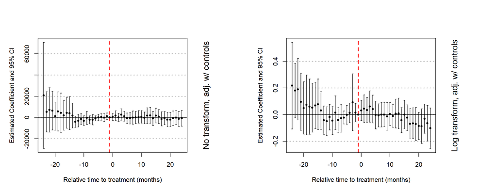

### 3.3.2 Opioids: Total Strength

**Outcome: baseline**

|  | No Transformation |  | Log Transformed |  |
| --- | --- | --- | --- | --- |
|  | (1) | (2) | (3) | (4) |
| Rec_disp | 47,449.710 | 17,913.560 | 0.070 | -0.094 |
|  | (59,832.050) | (50,259.280) | (0.144) | (0.082) |
| Rec_eff |  | 79,514.940 |  | 0.139 |
|  |  | (91,156.060) |  | (0.130) |
| Med_disp |  | -6,359.012 |  | -0.143 |
|  |  | (216,976.500) |  | (0.222) |
| Med_eff |  | 102,900.200 |  | 0.178 |
|  |  | (355,660.800) |  | (0.334) |
| Spillover |  | -86,479.570 |  | -0.096* |
|  |  | (53,320.420) |  | (0.056) |
| Population |  | 0.126 |  | 0.00000 |
|  |  | (0.077) |  | (0.00000) |
| Age |  | 1,864,753.000* |  | -1.355 |
|  |  | (953,359.900) |  | (1.205) |
| Gender |  | -425,337.700 |  | -4.319 |
|  |  | (1,685,107.000) |  | (4.838) |
| Race |  | 303,905.400 |  | 0.169 |
|  |  | (406,562.200) |  | (1.015) |
| MDI |  | -53,272.390 |  | -0.053 |
|  |  | (39,790.440) |  | (0.047) |
| Employment |  | -1,555,095.000** |  | -0.071 |
|  |  | (622,081.000) |  | (0.865) |
| Industry |  | 686,394.600* |  | 0.622 |
|  |  | (349,703.400) |  | (0.648) |
| Insurance_plan |  | 112,156.300 |  | 0.072 |
|  |  | (209,953.800) |  | (0.416) |
| Days_abs |  | -0.001 |  | -0.00000*** |
|  |  | (0.001) |  | (0.000) |
| MHD |  | 38.738** |  | 0.0001* |
|  |  | (17.931) |  | (0.0001) |
| AUD |  | 164.191 |  | 0.0003 |
|  |  | (119.077) |  | (0.0002) |
| Healthcare_exp |  | -25.928 |  | -0.00002 |
|  |  | (76.756) |  | (0.0001) |
| Hospitals |  | -132,046.400 |  | -0.264 |
|  |  | (152,293.100) |  | (0.180) |
| Officers |  | -190,155.200* |  | -0.325** |
|  |  | (97,015.240) |  | (0.144) |
| Crime |  | 21.142 |  | -0.00001 |
|  |  | (30.340) |  | (0.00003) |
| Drug_seize |  | -4,125.336 |  | -0.004 |
|  |  | (3,602.570) |  | (0.003) |
| Mandate_covid |  | -83,833.280 |  | -0.301 |
|  |  | (70,931.100) |  | (0.199) |
| Controls | No | Yes | No | Yes |
| FE: State/Year | Yes | Yes | Yes | Yes |
| Observations | 3,741 | 3,741 | 3,741 | 3,741 |
| R<sup>2</sup> | 0.411 | 0.486 | 0.504 | 0.844 |
| Adjusted R<sup>2</sup> | 0.389 | 0.464 | 0.486 | 0.837 |
| *Note:* | p<0.1; p<0.05; p<0.01 |  |  |  |
|  | Robust standard errors are clustered at the state level |  |  |  |

**Outcome: lead (6 months)**

|  | No Transformation |  | Log Transformed |  |
| --- | --- | --- | --- | --- |
|  | (1) | (2) | (3) | (4) |
| Rec_disp | 21,722.210 | -21,030.260 | 0.026 | -0.101 |
|  | (50,707.970) | (48,980.870) | (0.184) | (0.157) |
| Rec_eff |  | 75,199.320 |  | 0.308 |
|  |  | (52,877.610) |  | (0.186) |
| Med_disp |  | 51,400.490 |  | 0.019 |
|  |  | (142,494.100) |  | (0.163) |
| Med_eff |  | 1,846.825 |  | 0.080 |
|  |  | (253,269.000) |  | (0.236) |
| Spillover |  | -72,439.440 |  | -0.119* |
|  |  | (43,193.250) |  | (0.063) |
| Population |  | 0.104* |  | 0.00000 |
|  |  | (0.061) |  | (0.00000) |
| Age |  | 1,365,980.000* |  | 1.998 |
|  |  | (754,944.000) |  | (2.655) |
| Gender |  | 771,944.400 |  | 1.298 |
|  |  | (1,207,465.000) |  | (3.163) |
| Race |  | 183,339.200 |  | -0.936 |
|  |  | (353,794.600) |  | (0.947) |
| MDI |  | -27,331.090 |  | 0.041 |
|  |  | (27,599.960) |  | (0.063) |
| Employment |  | -1,631,082.000** |  | -1.256** |
|  |  | (667,499.800) |  | (0.473) |
| Industry |  | 718,843.600* |  | 1.035* |
|  |  | (372,738.800) |  | (0.552) |
| Insurance_plan |  | 216,155.400 |  | 0.749 |
|  |  | (193,919.300) |  | (0.525) |
| Days_abs |  | -0.003** |  | -0.00000*** |
|  |  | (0.001) |  | (0.000) |
| MHD |  | 24.368 |  | 0.00003 |
|  |  | (16.451) |  | (0.00003) |
| AUD |  | 176.145 |  | 0.0003 |
|  |  | (129.674) |  | (0.0002) |
| Healthcare_exp |  | -30.046 |  | -0.0002 |
|  |  | (76.925) |  | (0.0002) |
| Hospitals |  | -104,100.600 |  | -0.176 |
|  |  | (124,612.600) |  | (0.198) |
| Officers |  | -104,662.300 |  | -0.084 |
|  |  | (67,964.390) |  | (0.161) |
| Crime |  | 15.478 |  | 0.00002 |
|  |  | (16.359) |  | (0.00002) |
| Drug_seize |  | -3,738.869 |  | -0.003 |
|  |  | (3,349.263) |  | (0.003) |
| Mandate_covid |  | -59,630.540 |  | -0.253* |
|  |  | (41,441.110) |  | (0.150) |
| Controls | No | Yes | No | Yes |
| FE: State/Year | Yes | Yes | Yes | Yes |
| Observations | 3,483 | 3,483 | 3,483 | 3,483 |
| R<sup>2</sup> | 0.410 | 0.472 | 0.486 | 0.671 |
| Adjusted R<sup>2</sup> | 0.388 | 0.449 | 0.467 | 0.657 |
| *Note:* | p<0.1; p<0.05; p<0.01 |  |  |  |
|  | Robust standard errors are clustered at the state level |  |  |  |

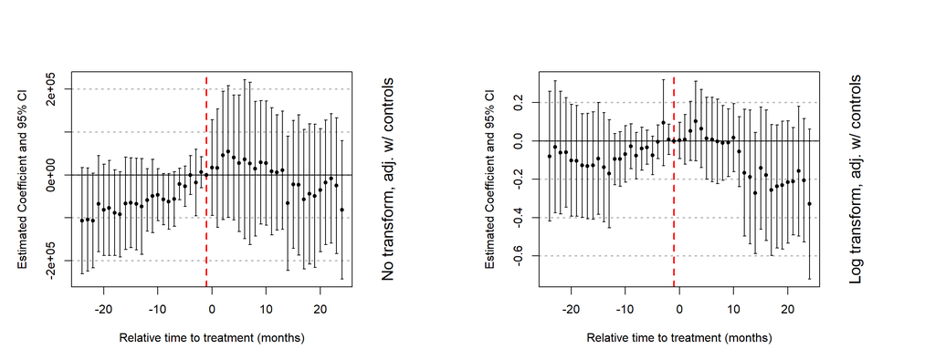

### 3.3.3 Opioids: Number

**Outcome: baseline**

|  | No Transformation |  | Log Transformed |  |
| --- | --- | --- | --- | --- |
|  | (1) | (2) | (3) | (4) |
| Rec_disp | 304.582 | 150.606 | 0.077 | -0.018 |
|  | (209.696) | (125.126) | (0.107) | (0.045) |
| Rec_eff |  | -105.013 |  | 0.001 |
|  |  | (101.995) |  | (0.034) |
| Med_disp |  | 12.115 |  | -0.001 |
|  |  | (97.110) |  | (0.026) |
| Med_eff |  | -132.557 |  | 0.020 |
|  |  | (109.611) |  | (0.031) |
| Spillover |  | -98.469** |  | -0.0003 |
|  |  | (47.026) |  | (0.018) |
| Population |  | 0.0003** |  | 0.00000 |
|  |  | (0.0001) |  | (0.00000) |
| Age |  | -7,423.366*** |  | -2.409*** |
|  |  | (1,046.525) |  | (0.473) |
| Gender |  | 8,373.171*** |  | -1.781 |
|  |  | (1,772.260) |  | (2.893) |
| Race |  | 1,076.461 |  | -0.156 |
|  |  | (711.006) |  | (0.333) |
| MDI |  | 66.799** |  | 0.010 |
|  |  | (30.832) |  | (0.012) |
| Employment |  | -285.733 |  | 0.402 |
|  |  | (321.659) |  | (0.420) |
| Industry |  | 1,023.077*** |  | -0.033 |
|  |  | (350.002) |  | (0.294) |
| Insurance_plan |  | -309.690 |  | -0.164 |
|  |  | (413.703) |  | (0.153) |
| Days_abs |  | -0.00000 |  | -0.000*** |
|  |  | (0.00000) |  | (0.000) |
| MHD |  | 0.153*** |  | 0.0001** |
|  |  | (0.026) |  | (0.00003) |
| AUD |  | 0.157 |  | 0.0002 |
|  |  | (0.155) |  | (0.0001) |
| Healthcare_exp |  | 0.282** |  | 0.00001 |
|  |  | (0.117) |  | (0.00004) |
| Hospitals |  | -253.388 |  | -0.018 |
|  |  | (307.465) |  | (0.088) |
| Officers |  | -279.806* |  | -0.035 |
|  |  | (143.473) |  | (0.051) |
| Crime |  | 0.027 |  | -0.00002** |
|  |  | (0.086) |  | (0.00001) |
| Drug_seize |  | 1.012 |  | 0.0001 |
|  |  | (1.298) |  | (0.001) |
| Mandate_covid |  | -247.310** |  | -0.058 |
|  |  | (114.851) |  | (0.052) |
| Controls | No | Yes | No | Yes |
| FE: State/Year | Yes | Yes | Yes | Yes |
| Observations | 3,741 | 3,741 | 3,741 | 3,741 |
| R<sup>2</sup> | 0.903 | 0.954 | 0.530 | 0.950 |
| Adjusted R<sup>2</sup> | 0.900 | 0.952 | 0.513 | 0.948 |
| *Note:* | p<0.1; p<0.05; p<0.01 |  |  |  |
|  | Robust standard errors are clustered at the state level |  |  |  |

**Outcome: lead (6 months)**

|  | No Transformation |  | Log Transformed |  |
| --- | --- | --- | --- | --- |
|  | (1) | (2) | (3) | (4) |
| Rec_disp | 298.895 | 81.574 | 0.081 | 0.008 |
|  | (231.202) | (136.317) | (0.115) | (0.079) |
| Rec_eff |  | 72.350 |  | 0.137 |
|  |  | (91.349) |  | (0.117) |
| Med_disp |  | 22.971 |  | 0.025 |
|  |  | (87.396) |  | (0.036) |
| Med_eff |  | -144.656 |  | 0.008 |
|  |  | (102.604) |  | (0.026) |
| Spillover |  | -105.552** |  | -0.024 |
|  |  | (43.551) |  | (0.027) |
| Population |  | 0.0003** |  | 0.00000 |
|  |  | (0.0001) |  | (0.00000) |
| Age |  | -4,222.388*** |  | 0.686 |
|  |  | (1,211.810) |  | (1.767) |
| Gender |  | 6,149.584*** |  | 0.257 |
|  |  | (1,804.076) |  | (1.840) |
| Race |  | 277.128 |  | -0.981 |
|  |  | (758.222) |  | (0.622) |
| MDI |  | 73.642** |  | 0.052 |
|  |  | (30.298) |  | (0.038) |
| Employment |  | -1,199.015*** |  | -0.280 |
|  |  | (415.840) |  | (0.260) |
| Industry |  | 710.337** |  | 0.096 |
|  |  | (321.398) |  | (0.232) |
| Insurance_plan |  | 115.186 |  | 0.277 |
|  |  | (320.283) |  | (0.298) |
| Days_abs |  | -0.00000* |  | -0.00000*** |
|  |  | (0.00000) |  | (0.000) |
| MHD |  | 0.139*** |  | 0.00004*** |
|  |  | (0.021) |  | (0.00001) |
| AUD |  | 0.058 |  | -0.00002 |
|  |  | (0.129) |  | (0.0001) |
| Healthcare_exp |  | 0.279** |  | -0.0001 |
|  |  | (0.113) |  | (0.0001) |
| Hospitals |  | -254.789 |  | 0.025 |
|  |  | (173.490) |  | (0.077) |
| Officers |  | -148.735 |  | 0.077 |
|  |  | (126.322) |  | (0.093) |
| Crime |  | 0.085 |  | 0.00001 |
|  |  | (0.079) |  | (0.00001) |
| Drug_seize |  | 2.391* |  | 0.001 |
|  |  | (1.297) |  | (0.001) |
| Mandate_covid |  | -206.170* |  | -0.073 |
|  |  | (104.099) |  | (0.065) |
| Controls | No | Yes | No | Yes |
| FE: State/Year | Yes | Yes | Yes | Yes |
| Observations | 3,483 | 3,483 | 3,483 | 3,483 |
| R<sup>2</sup> | 0.894 | 0.932 | 0.504 | 0.722 |
| Adjusted R<sup>2</sup> | 0.890 | 0.929 | 0.486 | 0.710 |
| *Note:* | p<0.1; p<0.05; p<0.01 |  |  |  |
|  | Robust standard errors are clustered at the state level |  |  |  |

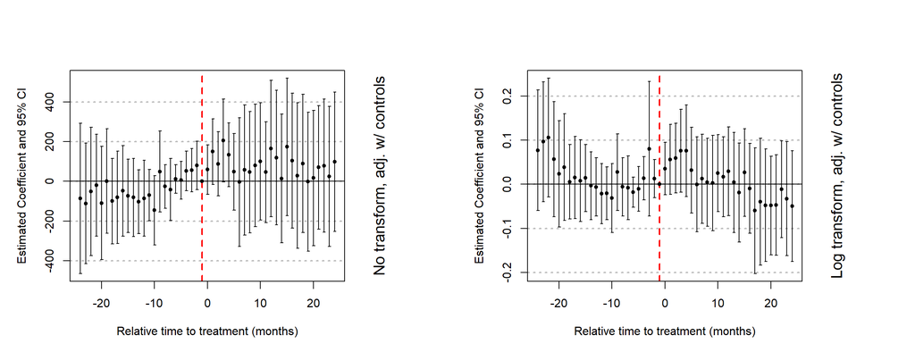

### 3.3.4 Opioids: Payment

**Outcome: baseline**

|  | No Transformation |  | Log Transformed |  |
| --- | --- | --- | --- | --- |
|  | (1) | (2) | (3) | (4) |
| Rec_disp | 9,845.549 | 3,008.977 | 0.155 | 0.024 |
|  | (12,030.550) | (12,327.450) | (0.148) | (0.083) |
| Rec_eff |  | -10,199.540 |  | -0.052 |
|  |  | (10,260.340) |  | (0.064) |
| Med_disp |  | -11,735.470 |  | -0.038 |
|  |  | (7,752.659) |  | (0.047) |
| Med_eff |  | -6,874.347 |  | -0.007 |
|  |  | (7,885.920) |  | (0.039) |
| Spillover |  | -2,923.368 |  | 0.004 |
|  |  | (3,326.978) |  | (0.026) |
| Population |  | 0.004 |  | 0.00000 |
|  |  | (0.012) |  | (0.00000) |
| Age |  | -267,537.600*** |  | -2.444*** |
|  |  | (62,568.710) |  | (0.483) |
| Gender |  | 394,436.900** |  | -2.800 |
|  |  | (155,938.600) |  | (4.430) |
| Race |  | -1,196.231 |  | -0.482 |
|  |  | (59,536.860) |  | (0.530) |
| MDI |  | 564.841 |  | -0.001 |
|  |  | (3,129.387) |  | (0.021) |
| Employment |  | -36,318.240 |  | 0.665 |
|  |  | (31,508.430) |  | (0.646) |
| Industry |  | 63,363.070** |  | -0.228 |
|  |  | (27,518.690) |  | (0.468) |
| Insurance_plan |  | -402.205 |  | -0.008 |
|  |  | (35,187.030) |  | (0.253) |
| Days_abs |  | -0.0001 |  | -0.00000*** |
|  |  | (0.0001) |  | (0.000) |
| MHD |  | 11.926*** |  | 0.0001*** |
|  |  | (1.870) |  | (0.00004) |
| AUD |  | -40.575* |  | -0.0003 |
|  |  | (23.655) |  | (0.0002) |
| Healthcare_exp |  | -4.177 |  | -0.0001 |
|  |  | (10.707) |  | (0.0001) |
| Hospitals |  | 7,041.795 |  | -0.058 |
|  |  | (17,955.380) |  | (0.140) |
| Officers |  | -13,560.660 |  | -0.066 |
|  |  | (11,045.440) |  | (0.119) |
| Crime |  | 2.930 |  | -0.00001 |
|  |  | (3.959) |  | (0.00001) |
| Drug_seize |  | 195.347 |  | 0.001 |
|  |  | (117.585) |  | (0.001) |
| Mandate_covid |  | -15,601.710** |  | -0.072 |
|  |  | (7,365.171) |  | (0.093) |
| Controls | No | Yes | No | Yes |
| FE: State/Year | Yes | Yes | Yes | Yes |
| Observations | 3,741 | 3,741 | 3,740 | 3,740 |
| R<sup>2</sup> | 0.722 | 0.769 | 0.497 | 0.898 |
| Adjusted R<sup>2</sup> | 0.712 | 0.759 | 0.479 | 0.893 |
| *Note:* | p<0.1; p<0.05; p<0.01 |  |  |  |
|  | Robust standard errors are clustered at the state level |  |  |  |

**Outcome: lead (6 months)**

|  | No Transformation |  | Log Transformed |  |
| --- | --- | --- | --- | --- |
|  | (1) | (2) | (3) | (4) |
| Rec_disp | 10,339.500 | 2,752.305 | 0.175 | 0.101 |
|  | (12,560.060) | (10,695.250) | (0.169) | (0.127) |
| Rec_eff |  | 301.483 |  | 0.161 |
|  |  | (8,497.519) |  | (0.174) |
| Med_disp |  | -14,958.700* |  | -0.031 |
|  |  | (7,771.564) |  | (0.066) |
| Med_eff |  | -10,308.440 |  | -0.036 |
|  |  | (7,432.657) |  | (0.049) |
| Spillover |  | -4,510.260 |  | -0.034 |
|  |  | (3,377.071) |  | (0.043) |
| Population |  | 0.010 |  | 0.00000 |
|  |  | (0.012) |  | (0.00000) |
| Age |  | -100,080.400 |  | 1.511 |
|  |  | (71,888.280) |  | (2.560) |
| Gender |  | 39,785.560 |  | -0.923 |
|  |  | (104,708.900) |  | (2.442) |
| Race |  | -62,010.830 |  | -2.047** |
|  |  | (58,929.070) |  | (0.928) |
| MDI |  | 3,164.342 |  | 0.078 |
|  |  | (2,175.792) |  | (0.056) |
| Employment |  | -50,619.030 |  | -0.119 |
|  |  | (36,155.910) |  | (0.379) |
| Industry |  | 21,001.570 |  | -0.180 |
|  |  | (19,085.130) |  | (0.341) |
| Insurance_plan |  | 1,287.260 |  | 0.462 |
|  |  | (28,289.820) |  | (0.447) |
| Days_abs |  | -0.00003 |  | -0.00000*** |
|  |  | (0.0001) |  | (0.000) |
| MHD |  | 8.298*** |  | 0.0001*** |
|  |  | (1.589) |  | (0.00002) |
| AUD |  | -13.111 |  | -0.0002* |
|  |  | (12.926) |  | (0.0001) |
| Healthcare_exp |  | -3.276 |  | -0.0002 |
|  |  | (9.092) |  | (0.0002) |
| Hospitals |  | 5,967.414 |  | 0.026 |
|  |  | (13,794.830) |  | (0.154) |
| Officers |  | -7,463.670 |  | 0.047 |
|  |  | (6,295.800) |  | (0.122) |
| Crime |  | 3.830 |  | 0.00003 |
|  |  | (4.751) |  | (0.00003) |
| Drug_seize |  | 162.964* |  | 0.002 |
|  |  | (90.920) |  | (0.002) |
| Mandate_covid |  | -16,778.460*** |  | -0.143 |
|  |  | (5,701.223) |  | (0.114) |
| Controls | No | Yes | No | Yes |
| FE: State/Year | Yes | Yes | Yes | Yes |
| Observations | 3,483 | 3,483 | 3,482 | 3,482 |
| R<sup>2</sup> | 0.698 | 0.725 | 0.479 | 0.685 |
| Adjusted R<sup>2</sup> | 0.687 | 0.713 | 0.460 | 0.672 |
| *Note:* | p<0.1; p<0.05; p<0.01 |  |  |  |
|  | Robust standard errors are clustered at the state level |  |  |  |

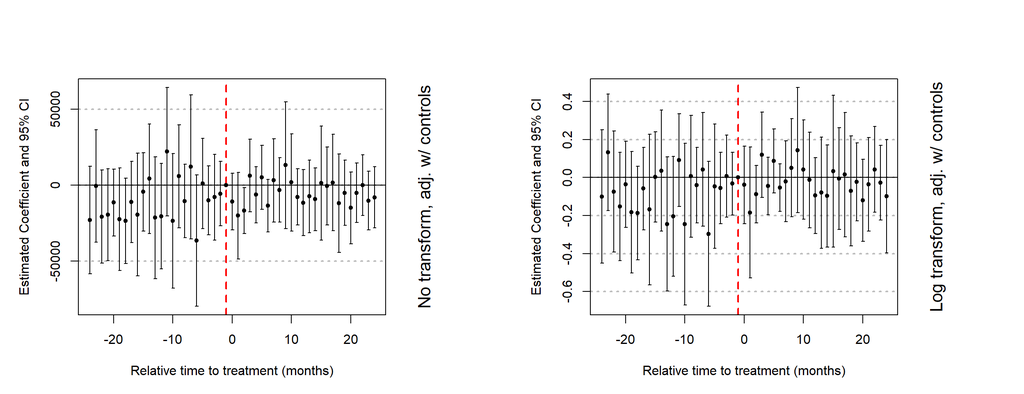

### 3.3.5 All Meds: Number

**Outcome: baseline**

|  | No Transformation |  | Log Transformed |  |
| --- | --- | --- | --- | --- |
|  | (1) | (2) | (3) | (4) |
| Rec_disp | 6,161.646 | 2,512.777 | 0.150 | -0.010 |
|  | (5,635.419) | (2,457.881) | (0.123) | (0.062) |
| Rec_eff |  | -163.262 |  | 0.011 |
|  |  | (1,244.923) |  | (0.045) |
| Med_disp |  | 478.170 |  | 0.012 |
|  |  | (1,055.422) |  | (0.026) |
| Med_eff |  | 1,733.180 |  | 0.042 |
|  |  | (1,344.423) |  | (0.031) |
| Spillover |  | -1,756.001* |  | -0.027 |
|  |  | (902.160) |  | (0.019) |
| Population |  | 0.003 |  | 0.00000 |
|  |  | (0.002) |  | (0.00000) |
| Age |  | -197,718.700*** |  | -2.522*** |
|  |  | (17,930.930) |  | (0.554) |
| Gender |  | 168,144.000*** |  | -4.240 |
|  |  | (38,997.110) |  | (4.164) |
| Race |  | 4,983.420 |  | 0.256 |
|  |  | (9,259.180) |  | (0.480) |
| MDI |  | 599.669 |  | 0.010 |
|  |  | (536.144) |  | (0.014) |
| Employment |  | -8,231.921 |  | 0.646 |
|  |  | (9,994.580) |  | (0.641) |
| Industry |  | 6,357.407 |  | -0.443 |
|  |  | (6,874.859) |  | (0.412) |
| Insurance_plan |  | -17,914.050** |  | -0.346** |
|  |  | (7,181.335) |  | (0.170) |
| Days_abs |  | -0.0001** |  | -0.00000*** |
|  |  | (0.00004) |  | (0.000) |
| MHD |  | 2.031*** |  | 0.0001** |
|  |  | (0.655) |  | (0.00004) |
| AUD |  | 3.737 |  | 0.0002* |
|  |  | (3.170) |  | (0.0001) |
| Healthcare_exp |  | -0.515 |  | 0.00001 |
|  |  | (1.596) |  | (0.00004) |
| Hospitals |  | -9,214.367 |  | -0.083 |
|  |  | (7,943.311) |  | (0.110) |
| Officers |  | -3,564.258 |  | -0.022 |
|  |  | (2,617.971) |  | (0.079) |
| Crime |  | -0.717 |  | -0.00002 |
|  |  | (0.480) |  | (0.00001) |
| Drug_seize |  | -8.194 |  | 0.0005 |
|  |  | (17.076) |  | (0.001) |
| Mandate_covid |  | -3,869.010** |  | -0.073 |
|  |  | (1,760.288) |  | (0.054) |
| Controls | No | Yes | No | Yes |
| FE: State/Year | Yes | Yes | Yes | Yes |
| Observations | 3,741 | 3,741 | 3,741 | 3,741 |
| R<sup>2</sup> | 0.750 | 0.925 | 0.204 | 0.937 |
| Adjusted R<sup>2</sup> | 0.741 | 0.921 | 0.176 | 0.934 |
| *Note:* | p<0.1; p<0.05; p<0.01 |  |  |  |
|  | Robust standard errors are clustered at the state level |  |  |  |

**Outcome: lead (6 months)**

|  | No Transformation |  | Log Transformed |  |
| --- | --- | --- | --- | --- |
|  | (1) | (2) | (3) | (4) |
| Rec_disp | 6,074.264 | 1,707.115 | 0.157 | 0.050 |
|  | (5,915.759) | (2,709.676) | (0.132) | (0.088) |
| Rec_eff |  | 3,159.983 |  | 0.183 |
|  |  | (2,614.316) |  | (0.168) |
| Med_disp |  | 760.774 |  | 0.046 |
|  |  | (1,341.349) |  | (0.047) |
| Med_eff |  | 392.106 |  | 0.026 |
|  |  | (1,826.376) |  | (0.038) |
| Spillover |  | -2,158.128*** |  | -0.053 |
|  |  | (768.618) |  | (0.036) |
| Population |  | 0.006** |  | 0.00000 |
|  |  | (0.003) |  | (0.00000) |
| Age |  | -96,545.460*** |  | 1.649 |
|  |  | (30,032.690) |  | (2.557) |
| Gender |  | 126,233.900*** |  | -0.931 |
|  |  | (38,393.200) |  | (2.524) |
| Race |  | -23,043.220* |  | -0.946 |
|  |  | (13,446.660) |  | (0.852) |
| MDI |  | 1,191.593* |  | 0.067 |
|  |  | (696.993) |  | (0.056) |
| Employment |  | -24,995.920** |  | -0.098 |
|  |  | (9,996.697) |  | (0.356) |
| Industry |  | 3,424.803 |  | -0.212 |
|  |  | (6,451.588) |  | (0.334) |
| Insurance_plan |  | -7,507.142 |  | 0.304 |
|  |  | (7,995.021) |  | (0.417) |
| Days_abs |  | -0.0002*** |  | -0.00000*** |
|  |  | (0.00003) |  | (0.000) |
| MHD |  | 1.672*** |  | 0.00003** |
|  |  | (0.511) |  | (0.00001) |
| AUD |  | 1.989 |  | 0.0001 |
|  |  | (2.925) |  | (0.0001) |
| Healthcare_exp |  | 0.215 |  | -0.0001 |
|  |  | (2.327) |  | (0.0002) |
| Hospitals |  | -5,120.191 |  | 0.024 |
|  |  | (4,809.573) |  | (0.109) |
| Officers |  | 371.896 |  | 0.116 |
|  |  | (2,417.800) |  | (0.139) |
| Crime |  | 0.162 |  | 0.00001 |
|  |  | (0.274) |  | (0.00002) |
| Drug_seize |  | 8.987 |  | 0.002 |
|  |  | (21.705) |  | (0.002) |
| Mandate_covid |  | -1,785.156 |  | -0.104 |
|  |  | (1,758.207) |  | (0.087) |
| Controls | No | Yes | No | Yes |
| FE: State/Year | Yes | Yes | Yes | Yes |
| Observations | 3,483 | 3,483 | 3,483 | 3,483 |
| R<sup>2</sup> | 0.740 | 0.832 | 0.208 | 0.571 |
| Adjusted R<sup>2</sup> | 0.730 | 0.825 | 0.179 | 0.552 |
| *Note:* | p<0.1; p<0.05; p<0.01 |  |  |  |
|  | Robust standard errors are clustered at the state level |  |  |  |

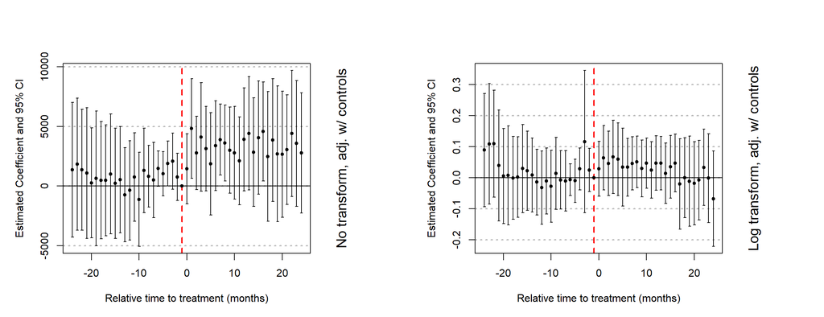

### 3.3.6 All Meds: Payment

**Outcome: baseline**

|  | No Transformation |  | Log Transformed |  |
| --- | --- | --- | --- | --- |
|  | (1) | (2) | (3) | (4) |
| Rec_disp | 659,356.900 | 270,017.900 | 0.193 | -0.019 |
|  | (1,012,974.000) | (301,406.200) | (0.174) | (0.075) |
| Rec_eff |  | -25,328.050 |  | 0.014 |
|  |  | (181,240.300) |  | (0.057) |
| Med_disp |  | 140,303.400 |  | 0.019 |
|  |  | (228,061.500) |  | (0.042) |
| Med_eff |  | 638,802.900** |  | 0.072 |
|  |  | (241,904.500) |  | (0.045) |
| Spillover |  | 65,717.650 |  | -0.025 |
|  |  | (117,051.400) |  | (0.027) |
| Population |  | 0.263 |  | 0.00000 |
|  |  | (0.397) |  | (0.00000) |
| Age |  | -31,977,925.000*** |  | -2.790*** |
|  |  | (2,924,569.000) |  | (0.795) |
| Gender |  | 28,294,506.000*** |  | -6.832 |
|  |  | (7,845,376.000) |  | (6.220) |
| Race |  | -3,848,235.000 |  | 0.220 |
|  |  | (2,938,617.000) |  | (0.783) |
| MDI |  | 5,096.590 |  | 0.010 |
|  |  | (89,584.840) |  | (0.019) |
| Employment |  | -2,576,769.000 |  | 0.920 |
|  |  | (2,100,942.000) |  | (0.961) |
| Industry |  | 2,910,433.000** |  | -0.514 |
|  |  | (1,273,829.000) |  | (0.613) |
| Insurance_plan |  | -1,646,812.000 |  | -0.348 |
|  |  | (1,117,501.000) |  | (0.256) |
| Days_abs |  | -0.024** |  | -0.00000*** |
|  |  | (0.009) |  | (0.000) |
| MHD |  | 480.571*** |  | 0.0001** |
|  |  | (151.639) |  | (0.0001) |
| AUD |  | 1,115.550 |  | 0.0004* |
|  |  | (968.821) |  | (0.0002) |
| Healthcare_exp |  | -535.922* |  | -0.00003 |
|  |  | (270.404) |  | (0.0001) |
| Hospitals |  | -1,512,335.000 |  | -0.075 |
|  |  | (1,067,119.000) |  | (0.153) |
| Officers |  | -1,138,375.000** |  | -0.049 |
|  |  | (493,124.200) |  | (0.133) |
| Crime |  | -190.908 |  | -0.00002 |
|  |  | (187.360) |  | (0.00002) |
| Drug_seize |  | -3,004.815 |  | 0.001 |
|  |  | (3,925.024) |  | (0.001) |
| Mandate_covid |  | -140,787.700 |  | -0.104 |
|  |  | (340,856.500) |  | (0.082) |
| Controls | No | Yes | No | Yes |
| FE: State/Year | Yes | Yes | Yes | Yes |
| Observations | 3,741 | 3,741 | 3,741 | 3,741 |
| R<sup>2</sup> | 0.699 | 0.915 | 0.144 | 0.931 |
| Adjusted R<sup>2</sup> | 0.688 | 0.911 | 0.114 | 0.929 |
| *Note:* | p<0.1; p<0.05; p<0.01 |  |  |  |
|  | Robust standard errors are clustered at the state level |  |  |  |

**Outcome: lead (6 months)**

|  | No Transformation |  | Log Transformed |  |
| --- | --- | --- | --- | --- |
|  | (1) | (2) | (3) | (4) |
| Rec_disp | 628,808.000 | 220,962.900 | 0.198 | 0.074 |
|  | (1,076,885.000) | (412,124.400) | (0.187) | (0.118) |
| Rec_eff |  | 439,929.700 |  | 0.253 |
|  |  | (426,680.500) |  | (0.244) |
| Med_disp |  | 178,343.500 |  | 0.066 |
|  |  | (240,582.400) |  | (0.069) |
| Med_eff |  | 366,639.200 |  | 0.049 |
|  |  | (298,757.300) |  | (0.053) |
| Spillover |  | -22,989.920 |  | -0.059 |
|  |  | (136,397.500) |  | (0.054) |
| Population |  | 0.731 |  | 0.00000 |
|  |  | (0.462) |  | (0.00000) |
| Age |  | -13,856,057.000** |  | 3.074 |
|  |  | (5,528,165.000) |  | (3.739) |
| Gender |  | 23,996,011.000*** |  | -1.608 |
|  |  | (7,569,029.000) |  | (3.720) |
| Race |  | -9,154,799.000*** |  | -1.550 |
|  |  | (3,053,471.000) |  | (1.253) |
| MDI |  | 202,421.300 |  | 0.097 |
|  |  | (128,399.600) |  | (0.081) |
| Employment |  | -5,863,818.000*** |  | -0.152 |
|  |  | (1,911,059.000) |  | (0.486) |
| Industry |  | 2,303,131.000* |  | -0.188 |
|  |  | (1,213,456.000) |  | (0.490) |
| Insurance_plan |  | -102,963.500 |  | 0.567 |
|  |  | (1,386,948.000) |  | (0.609) |
| Days_abs |  | -0.048*** |  | -0.00000*** |
|  |  | (0.007) |  | (0.000) |
| MHD |  | 388.500*** |  | 0.0001** |
|  |  | (124.915) |  | (0.00002) |
| AUD |  | 677.779 |  | 0.0001 |
|  |  | (584.753) |  | (0.0001) |
| Healthcare_exp |  | -497.930 |  | -0.0002 |
|  |  | (400.229) |  | (0.0002) |
| Hospitals |  | -813,238.200 |  | 0.096 |
|  |  | (681,901.000) |  | (0.158) |
| Officers |  | -332,180.500 |  | 0.141 |
|  |  | (534,443.500) |  | (0.207) |
| Crime |  | -133.593 |  | 0.00001 |
|  |  | (139.805) |  | (0.00002) |
| Drug_seize |  | 1,053.805 |  | 0.003 |
|  |  | (4,540.843) |  | (0.002) |
| Mandate_covid |  | 178,343.200 |  | -0.157 |
|  |  | (366,164.100) |  | (0.128) |
| Controls | No | Yes | No | Yes |
| FE: State/Year | Yes | Yes | Yes | Yes |
| Observations | 3,483 | 3,483 | 3,483 | 3,483 |
| R<sup>2</sup> | 0.698 | 0.813 | 0.152 | 0.545 |
| Adjusted R<sup>2</sup> | 0.687 | 0.805 | 0.121 | 0.525 |
| *Note:* | p<0.1; p<0.05; p<0.01 |  |  |  |
|  | Robust standard errors are clustered at the state level |  |  |  |

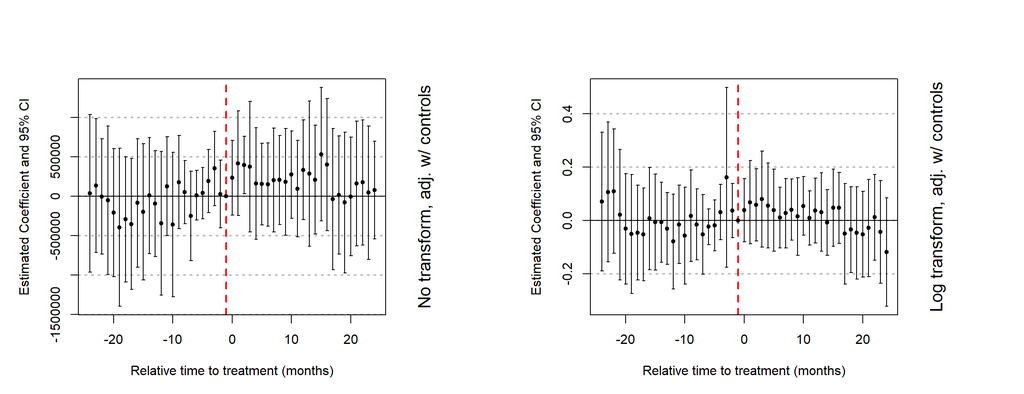

### 3.3.7 MHD Meds: Number

**Outcome: baseline**

|  | No Transformation |  | Log Transformed |  |
| --- | --- | --- | --- | --- |
|  | (1) | (2) | (3) | (4) |
| Rec_disp | 841.744 | 376.316 | 0.130 | -0.005 |
|  | (745.089) | (598.131) | (0.105) | (0.062) |
| Rec_eff |  | -414.531 |  | -0.008 |
|  |  | (286.262) |  | (0.040) |
| Med_disp |  | -144.645 |  | -0.007 |
|  |  | (184.105) |  | (0.024) |
| Med_eff |  | 351.386 |  | 0.041 |
|  |  | (248.539) |  | (0.027) |
| Spillover |  | -300.250* |  | -0.025 |
|  |  | (150.188) |  | (0.017) |
| Population |  | 0.0002 |  | 0.00000 |
|  |  | (0.0005) |  | (0.00000) |
| Age |  | -21,121.930*** |  | -1.687*** |
|  |  | (2,765.655) |  | (0.435) |
| Gender |  | 23,283.630** |  | -3.639 |
|  |  | (9,717.024) |  | (3.619) |
| Race |  | -978.399 |  | 0.185 |
|  |  | (2,263.064) |  | (0.446) |
| MDI |  | 251.285** |  | 0.018 |
|  |  | (121.975) |  | (0.014) |
| Employment |  | -1,085.596 |  | 0.582 |
|  |  | (1,748.926) |  | (0.554) |
| Industry |  | -1,399.391 |  | -0.525 |
|  |  | (1,626.172) |  | (0.365) |
| Insurance_plan |  | -3,569.687** |  | -0.353** |
|  |  | (1,453.836) |  | (0.154) |
| Days_abs |  | -0.00002** |  | -0.000*** |
|  |  | (0.00001) |  | (0.000) |
| MHD |  | 0.545*** |  | 0.0001** |
|  |  | (0.171) |  | (0.00004) |
| AUD |  | 1.583 |  | 0.0002* |
|  |  | (0.944) |  | (0.0001) |
| Healthcare_exp |  | 0.062 |  | 0.00002 |
|  |  | (0.310) |  | (0.00003) |
| Hospitals |  | -1,523.658 |  | -0.062 |
|  |  | (1,282.545) |  | (0.098) |
| Officers |  | -320.012 |  | 0.005 |
|  |  | (584.409) |  | (0.072) |
| Crime |  | -0.123 |  | -0.00001 |
|  |  | (0.084) |  | (0.00001) |
| Drug_seize |  | 1.136 |  | 0.001 |
|  |  | (4.461) |  | (0.001) |
| Mandate_covid |  | -967.783** |  | -0.088* |
|  |  | (391.094) |  | (0.051) |
| Controls | No | Yes | No | Yes |
| FE: State/Year | Yes | Yes | Yes | Yes |
| Observations | 3,741 | 3,741 | 3,741 | 3,741 |
| R<sup>2</sup> | 0.735 | 0.902 | 0.219 | 0.934 |
| Adjusted R<sup>2</sup> | 0.725 | 0.898 | 0.191 | 0.931 |
| *Note:* | p<0.1; p<0.05; p<0.01 |  |  |  |
|  | Robust standard errors are clustered at the state level |  |  |  |

**Outcome: lead (6 months)**

|  | No Transformation |  | Log Transformed |  |
| --- | --- | --- | --- | --- |
|  | (1) | (2) | (3) | (4) |
| Rec_disp | 930.816 | 447.255 | 0.140 | 0.053 |
|  | (841.806) | (600.103) | (0.114) | (0.079) |
| Rec_eff |  | 130.209 |  | 0.139 |
|  |  | (408.377) |  | (0.143) |
| Med_disp |  | 44.818 |  | 0.029 |
|  |  | (260.170) |  | (0.043) |
| Med_eff |  | 72.758 |  | 0.024 |
|  |  | (365.185) |  | (0.038) |
| Spillover |  | -355.995** |  | -0.046 |
|  |  | (138.555) |  | (0.032) |
| Population |  | 0.001 |  | 0.00000 |
|  |  | (0.001) |  | (0.00000) |
| Age |  | -6,818.746 |  | 1.767 |
|  |  | (5,717.614) |  | (2.218) |
| Gender |  | 21,035.780** |  | -0.671 |
|  |  | (9,155.170) |  | (2.205) |
| Race |  | -5,300.065* |  | -0.843 |
|  |  | (2,650.403) |  | (0.734) |
| MDI |  | 329.737** |  | 0.065 |
|  |  | (151.987) |  | (0.049) |
| Employment |  | -5,345.388*** |  | -0.141 |
|  |  | (1,780.742) |  | (0.297) |
| Industry |  | -965.132 |  | -0.283 |
|  |  | (1,492.767) |  | (0.290) |
| Insurance_plan |  | -1,745.352 |  | 0.209 |
|  |  | (1,486.049) |  | (0.365) |
| Days_abs |  | -0.00005*** |  | -0.00000*** |
|  |  | (0.00001) |  | (0.000) |
| MHD |  | 0.377** |  | 0.00003** |
|  |  | (0.141) |  | (0.00001) |
| AUD |  | 1.106 |  | 0.0001 |
|  |  | (0.716) |  | (0.0001) |
| Healthcare_exp |  | 0.094 |  | -0.0001 |
|  |  | (0.386) |  | (0.0001) |
| Hospitals |  | -893.278 |  | 0.026 |
|  |  | (859.153) |  | (0.098) |
| Officers |  | 356.430 |  | 0.125 |
|  |  | (460.533) |  | (0.118) |
| Crime |  | 0.046 |  | 0.00001 |
|  |  | (0.068) |  | (0.00002) |
| Drug_seize |  | 3.874 |  | 0.002 |
|  |  | (4.850) |  | (0.001) |
| Mandate_covid |  | -738.602* |  | -0.117 |
|  |  | (417.812) |  | (0.078) |
| Controls | No | Yes | No | Yes |
| FE: State/Year | Yes | Yes | Yes | Yes |
| Observations | 3,483 | 3,483 | 3,483 | 3,483 |
| R<sup>2</sup> | 0.734 | 0.827 | 0.223 | 0.579 |
| Adjusted R<sup>2</sup> | 0.724 | 0.820 | 0.195 | 0.561 |
| *Note:* | p<0.1; p<0.05; p<0.01 |  |  |  |
|  | Robust standard errors are clustered at the state level |  |  |  |

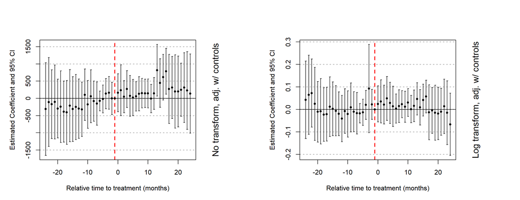

### 3.3.8 MHD Meds: Payment

**Outcome: baseline**

|  | No Transformation |  | Log Transformed |  |
| --- | --- | --- | --- | --- |
|  | (1) | (2) | (3) | (4) |
| Rec_disp | 24,336.600 | 4,770.257 | 0.151 | -0.014 |
|  | (35,199.560) | (42,153.600) | (0.144) | (0.088) |
| Rec_eff |  | -35,924.390 |  | -0.028 |
|  |  | (25,240.780) |  | (0.060) |
| Med_disp |  | -837.186 |  | 0.019 |
|  |  | (19,073.040) |  | (0.040) |
| Med_eff |  | 40,340.060* |  | 0.076* |
|  |  | (20,788.330) |  | (0.043) |
| Spillover |  | 536.537 |  | -0.013 |
|  |  | (11,129.290) |  | (0.025) |
| Population |  | 0.001 |  | 0.00000 |
|  |  | (0.028) |  | (0.00000) |
| Age |  | -605,396.900*** |  | -0.967 |
|  |  | (210,728.000) |  | (0.700) |
| Gender |  | 1,013,224.000 |  | -5.835 |
|  |  | (856,717.800) |  | (5.385) |
| Race |  | -83,149.640 |  | 0.210 |
|  |  | (147,396.800) |  | (0.593) |
| MDI |  | 5,678.970 |  | 0.016 |
|  |  | (8,276.391) |  | (0.021) |
| Employment |  | -165,631.100 |  | 0.545 |
|  |  | (138,832.100) |  | (0.841) |
| Industry |  | 73,937.720 |  | -0.423 |
|  |  | (142,611.900) |  | (0.560) |
| Insurance_plan |  | -47,615.080 |  | -0.233 |
|  |  | (105,676.500) |  | (0.218) |
| Days_abs |  | -0.002** |  | -0.00000*** |
|  |  | (0.001) |  | (0.000) |
| MHD |  | 56.958*** |  | 0.0001** |
|  |  | (15.445) |  | (0.0001) |
| AUD |  | 189.186* |  | 0.0005** |
|  |  | (97.917) |  | (0.0002) |
| Healthcare_exp |  | -14.111 |  | 0.00001 |
|  |  | (31.387) |  | (0.0001) |
| Hospitals |  | -85,197.120 |  | -0.025 |
|  |  | (83,411.290) |  | (0.117) |
| Officers |  | -64,390.160 |  | -0.025 |
|  |  | (45,878.250) |  | (0.102) |
| Crime |  | -16.599 |  | -0.00002 |
|  |  | (13.924) |  | (0.00002) |
| Drug_seize |  | -143.792 |  | 0.001 |
|  |  | (405.165) |  | (0.001) |
| Mandate_covid |  | -23,644.130 |  | -0.074 |
|  |  | (36,245.490) |  | (0.080) |
| Controls | No | Yes | No | Yes |
| FE: State/Year | Yes | Yes | Yes | Yes |
| Observations | 3,741 | 3,741 | 3,741 | 3,741 |
| R<sup>2</sup> | 0.690 | 0.862 | 0.163 | 0.923 |
| Adjusted R<sup>2</sup> | 0.679 | 0.857 | 0.133 | 0.920 |
| *Note:* | p<0.1; p<0.05; p<0.01 |  |  |  |
|  | Robust standard errors are clustered at the state level |  |  |  |

**Outcome: lead (6 months)**

|  | No Transformation |  | Log Transformed |  |
| --- | --- | --- | --- | --- |
|  | (1) | (2) | (3) | (4) |
| Rec_disp | 32,290.680 | 19,933.160 | 0.170 | 0.083 |
|  | (41,665.720) | (40,603.250) | (0.158) | (0.111) |
| Rec_eff |  | -9,191.252 |  | 0.172 |
|  |  | (31,102.990) |  | (0.207) |
| Med_disp |  | 11,083.020 |  | 0.065 |
|  |  | (23,154.960) |  | (0.063) |
| Med_eff |  | 5,760.792 |  | 0.041 |
|  |  | (25,982.240) |  | (0.050) |
| Spillover |  | -6,603.857 |  | -0.046 |
|  |  | (10,402.750) |  | (0.046) |
| Population |  | 0.010 |  | 0.00000 |
|  |  | (0.035) |  | (0.00000) |
| Age |  | 341,325.100 |  | 3.847 |
|  |  | (439,813.900) |  | (3.195) |
| Gender |  | 1,162,201.000 |  | -1.328 |
|  |  | (803,107.000) |  | (3.312) |
| Race |  | -400,086.100** |  | -1.200 |
|  |  | (190,026.900) |  | (1.097) |
| MDI |  | 14,530.910 |  | 0.087 |
|  |  | (10,744.940) |  | (0.070) |
| Employment |  | -478,573.300*** |  | -0.528 |
|  |  | (141,621.300) |  | (0.432) |
| Industry |  | 92,043.520 |  | -0.125 |
|  |  | (132,996.800) |  | (0.433) |
| Insurance_plan |  | 18,842.820 |  | 0.505 |
|  |  | (113,254.300) |  | (0.525) |
| Days_abs |  | -0.004*** |  | -0.00000*** |
|  |  | (0.001) |  | (0.000) |
| MHD |  | 37.706*** |  | 0.0001*** |
|  |  | (12.381) |  | (0.00002) |
| AUD |  | 166.256*** |  | 0.0003** |
|  |  | (60.866) |  | (0.0001) |
| Healthcare_exp |  | -23.107 |  | -0.0002 |
|  |  | (28.826) |  | (0.0002) |
| Hospitals |  | -59,990.010 |  | 0.087 |
|  |  | (60,749.930) |  | (0.140) |
| Officers |  | -17,999.740 |  | 0.152 |
|  |  | (37,737.850) |  | (0.166) |
| Crime |  | -5.830 |  | 0.00001 |
|  |  | (7.156) |  | (0.00002) |
| Drug_seize |  | 100.003 |  | 0.002 |
|  |  | (430.762) |  | (0.002) |
| Mandate_covid |  | -29,290.020 |  | -0.144 |
|  |  | (38,729.990) |  | (0.115) |
| Controls | No | Yes | No | Yes |
| FE: State/Year | Yes | Yes | Yes | Yes |
| Observations | 3,483 | 3,483 | 3,483 | 3,483 |
| R<sup>2</sup> | 0.690 | 0.791 | 0.167 | 0.551 |
| Adjusted R<sup>2</sup> | 0.679 | 0.782 | 0.137 | 0.532 |
| *Note:* | p<0.1; p<0.05; p<0.01 |  |  |  |
|  | Robust standard errors are clustered at the state level |  |  |  |

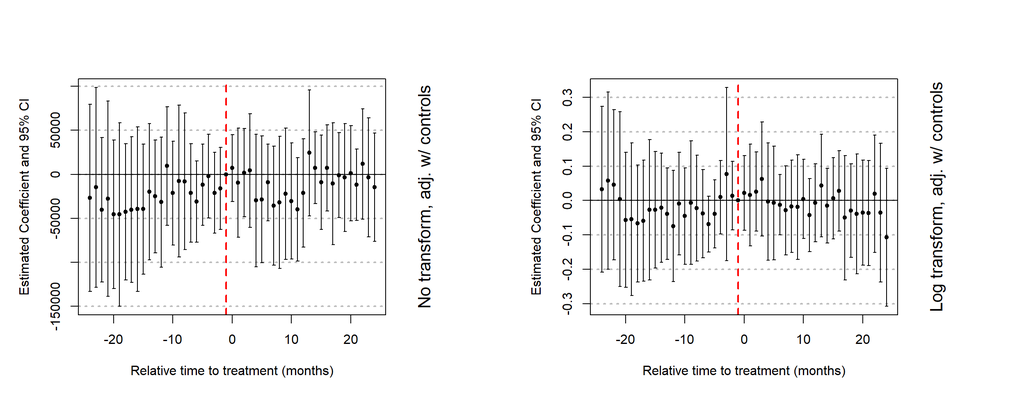